# pstat131_project

Michael Rhine-6342398

12/16/2020

# **PSTAT 131 FINAL PROJECT: 2020 ELELECTION ANALYSIS**

**Professor Guo Yu)** **Michael Rhine 6342398** **December 17, 2020**

## **DATA**

Load in the two data sets. The first data-set is/was the latest data of the 2020 US Election. The second data-set is the 2017 United State county-level census data.

Use the given code to load in the data.

### **1.ELECTION DATA**

*Report the dimension of election.raw. Are there missing values in the data set? Compute the total number of distinct values in state in election.raw to verify that the data contains all states and a federal district.*

```
## [1] 31167     5
```

```
## [1] 51
```

The dimensions for election.raw is 31,167 rows by 5 columns.

To compute the total number of distinct values in state in the data-set, we can generate a vector for all unique values in the state column. Then, we can compute the length to get a value of 51, which tells us that all states and the District of Columbia are contained in the data.

### **2. CENSUS DATA**

*Report the dimension of census. Are there missing values in the data set? Compute the total number of distinct values in county in census. Compare the values of total number of distinct county in census with that in election.raw. Comment on your findings.*

```
## [1] "Dimensions of census:  3220" "Dimensions of census:  37"
```

```
## [1] "Does census contain missing data?  1"
```

```
## [1] "Number of census counties:  1955"
```

```
## [1] "Number of election.raw counties:  2825"
```

```r
#Find missing data
apply(is.na(census),2,which)
```

```
## $CountyId
## integer(0)
##
## $State
## integer(0)
##
## $County
## integer(0)
##
## $TotalPop
## integer(0)
##
## $Men
## integer(0)
##
## $Women
## integer(0)
##
## $Hispanic
## integer(0)
##
## $White
## integer(0)
##
## $Black
## integer(0)
##
## $Native
## integer(0)
##
## $Asian
## integer(0)
##
## $Pacific
## integer(0)
##
## $VotingAgeCitizen
## integer(0)
##
## $Income
```

[output cut: 55 more lines]

```
##
## $PrivateWork
## integer(0)
##
## $PublicWork
## integer(0)
##
## $SelfEmployed
## integer(0)
##
## $FamilyWork
## integer(0)
##
## $Unemployment
## integer(0)
```

```r
#Replace missing values with mean value for ChildPoverty
new_val = mean(census$ChildPoverty, na.rm=TRUE)
census$ChildPoverty[is.na(census$ChildPoverty)] = new_val
```

```r
#Double Check
apply(is.na(census),2,which)
```

```
## integer(0)
```

## **DATA WRANGLING**

### **3.**

*Construct aggregated data sets from election.raw data: ie.,* *Keep the county-level data as it is in election.raw.* *Create a state-level summary into a election.state.* *Create a federal-level summary into a election.total.*

```
## # A tibble: 6 x 5
##   state    county     candidate     party  votes
##   <chr>    <chr>      <fct>         <fct>  <dbl>
## 1 Delaware Kent       Joe Biden     DEM    44518
## 2 Delaware Kent       Donald Trump  REP    40976
## 3 Delaware Kent       Jo Jorgensen  LIB     1044
## 4 Delaware Kent       Howie Hawkins GRN      420
## 5 Delaware Kent       Write-ins     WRI        0
## 6 Delaware New Castle Joe Biden     DEM   194238
```

```
## # A tibble: 6 x 3
## # Groups:   state [2]
##   state   candidate         votes
##   <chr>   <fct>             <dbl>
## 1 Alabama Donald Trump    1434159
## 2 Alabama Jo Jorgensen      24994
## 3 Alabama Joe Biden        843473
## 4 Alabama Write-ins          7274
## 5 Alaska  Brock Pierce        297
## 6 Alaska  Don Blankenship     348
```

```
## # A tibble: 6 x 2
##   candidate             votes
##   <fct>                 <dbl>
## 1 Joe Biden          76193955
## 2 Donald Trump       71500110
## 3 Jo Jorgensen        1756245
## 4 Howie Hawkins        358496
## 5 Write-ins            160572
## 6 Rocky De La Fuente    71146
```

```r
paste("Dimensions of election.county (votes per candidate per county):",dim(election.county))
```

```
## [1] "Dimensions of election.county (votes per candidate per county): 31167"
## [2] "Dimensions of election.county (votes per candidate per county): 5"
```

```r
paste("Dimensions of election.state (votes per candidate per state):", dim(election.state))
```

```
## [1] "Dimensions of election.state (votes per candidate per state): 351"
## [2] "Dimensions of election.state (votes per candidate per state): 3"
```

```r
paste("Dimensions of election.total (total votes per candidate):", dim(election.total))
```

```
## [1] "Dimensions of election.total (total votes per candidate): 38"
## [2] "Dimensions of election.total (total votes per candidate): 2"
```

### **4.**

*How many named presidential candidates were there in the 2020 election? Draw a bar chart of all votes received by each candidate. You can split this into multiple plots or may prefer to plot the results on a log scale. Either way, the results should be clear and legible! (For fun: spot Kanye West among the presidential candidates!)*

```
## [1] 38  2
```

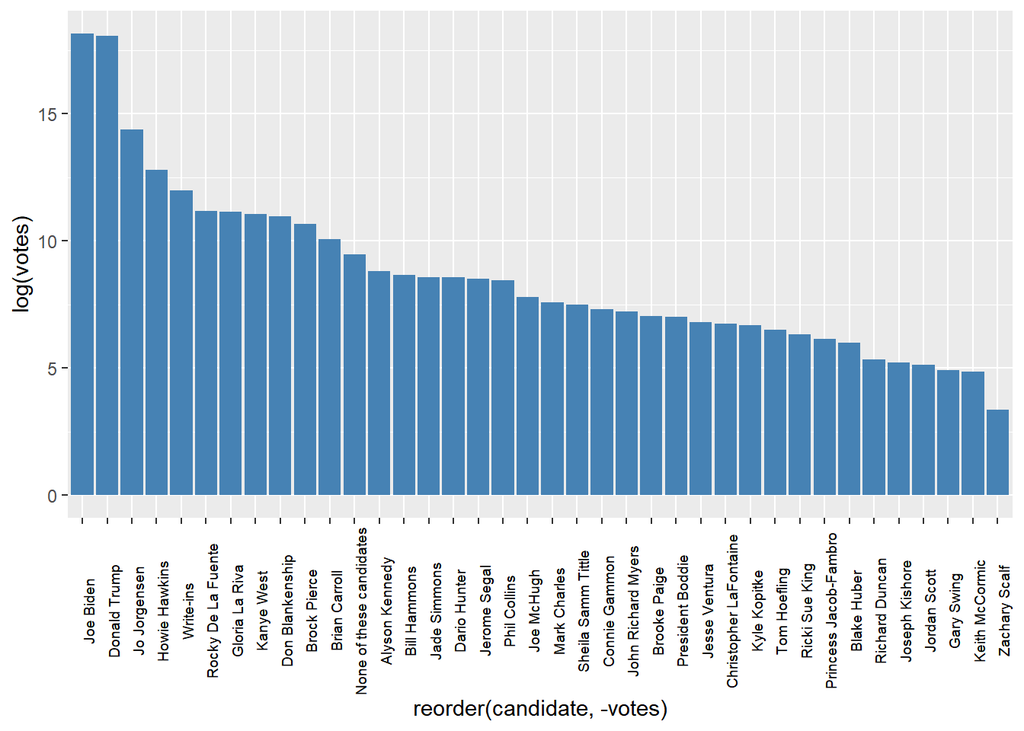

```r
#remove scientific notation
options(scipen=999)
#Seperating election total into subsets by votes
el.tot_1 = election.total[1:3,]
el.tot_2 = election.total[3:12,]
el.tot_3 = election.total[13:38,]


el.tot_1.plot <- ggplot(data=el.tot_1, aes(x=reorder(candidate,-votes))) +
  geom_bar(aes(y=votes), stat='identity', fill='steelblue') +
  theme(axis.text.x=element_text(color='black',size=7,angle=90))

el.tot_2.plot <- ggplot(data=el.tot_2, aes(x=reorder(candidate,-votes))) +
  geom_bar(aes(y=votes), stat='identity', fill='steelblue') +
  theme(axis.text.x=element_text(color='black',size=7,angle=90))

el.tot_3.plot <- ggplot(data=el.tot_3, aes(x=reorder(candidate,-votes))) +
  geom_bar(aes(y=votes), stat='identity', fill='steelblue') +
  theme(axis.text.x=element_text(color='black',size=7,angle=90))
```

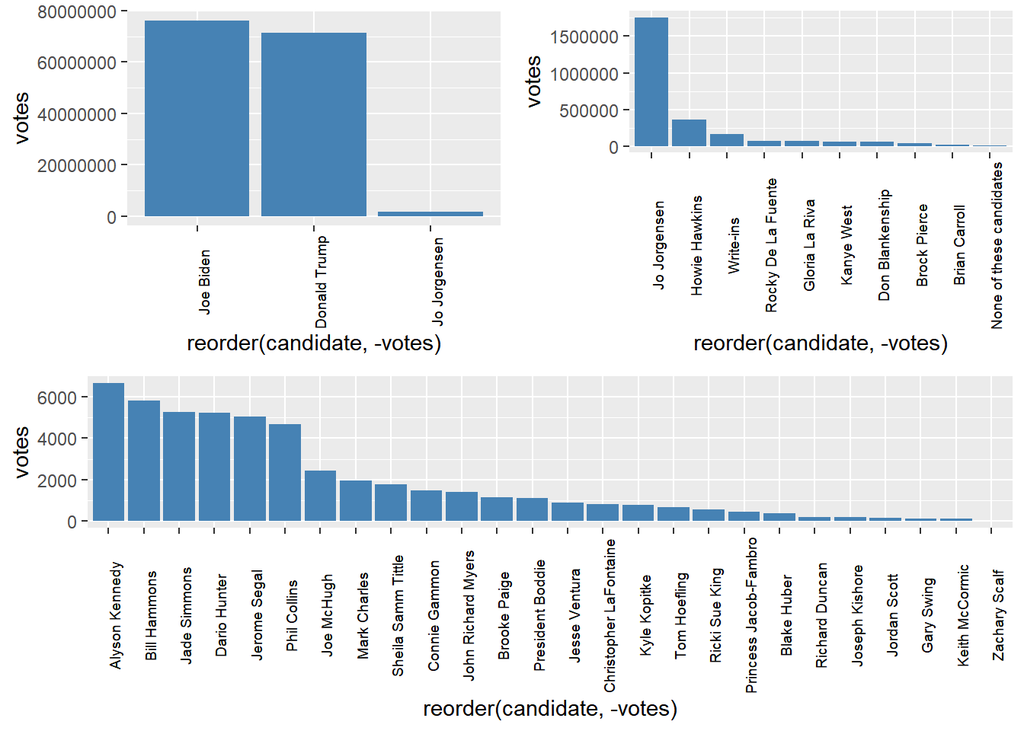

```r
grid.arrange(el.tot_1.plot,el.tot_2.plot,el.tot_3.plot,
             layout_matrix = rbind(c(1,2,NA),
                                   c(3,3,NA)))
```

### **5.**

*Create data sets county.winner and state.winner by taking the candidate with the highest proportion of votes in both county level and state level. Hint: to create county.winner, start with election.raw, group by county, compute total votes, and pct = votes/total as the proportion of votes. Then choose the highest row using top_n (variable state.winner is similar).*

```
## # A tibble: 2,720 x 7
## # Groups:   county [2,718]
##    state                county               candidate party  votes  total   pct
##    <chr>                <chr>                <fct>     <fct>  <dbl>  <dbl> <dbl>
##  1 Delaware             New Castle           Joe Biden DEM   194238 287047 0.677
##  2 Delaware             Sussex               Donald T~ REP    71196 202727 0.351
##  3 District of Columbia District of Columbia Joe Biden DEM    29509  31260 0.944
##  4 District of Columbia Ward 2               Joe Biden DEM    24247  27259 0.890
##  5 District of Columbia Ward 3               Joe Biden DEM    33584  37377 0.899
##  6 District of Columbia Ward 4               Joe Biden DEM    35117  37223 0.943
##  7 District of Columbia Ward 5               Joe Biden DEM    36585  38778 0.943
##  8 District of Columbia Ward 6               Joe Biden DEM    44699  49394 0.905
##  9 District of Columbia Ward 7               Joe Biden DEM    30253  31823 0.951
## 10 District of Columbia Ward 8               Joe Biden DEM    24567  26038 0.944
## # ... with 2,710 more rows
```

```
## # A tibble: 51 x 5
## # Groups:   state [51]
##    state                candidate      votes    total   pct
##    <chr>                <fct>          <dbl>    <dbl> <dbl>
##  1 Alabama              Donald Trump 1434159  2309900 0.621
##  2 Alaska               Donald Trump   80999   131885 0.614
##  3 Arizona              Joe Biden    1643664  3322535 0.495
##  4 Arkansas             Donald Trump  761251  1216818 0.626
##  5 California           Joe Biden    9315259 14414296 0.646
##  6 Colorado             Joe Biden    1753416  3173127 0.553
##  7 Connecticut          Joe Biden    1059252  1786557 0.593
##  8 Delaware             Joe Biden     295413   502384 0.588
##  9 District of Columbia Joe Biden     258561   279152 0.926
## 10 Florida              Donald Trump 5667834 11075706 0.512
## # ... with 41 more rows
```

## **VISUALIZATION**

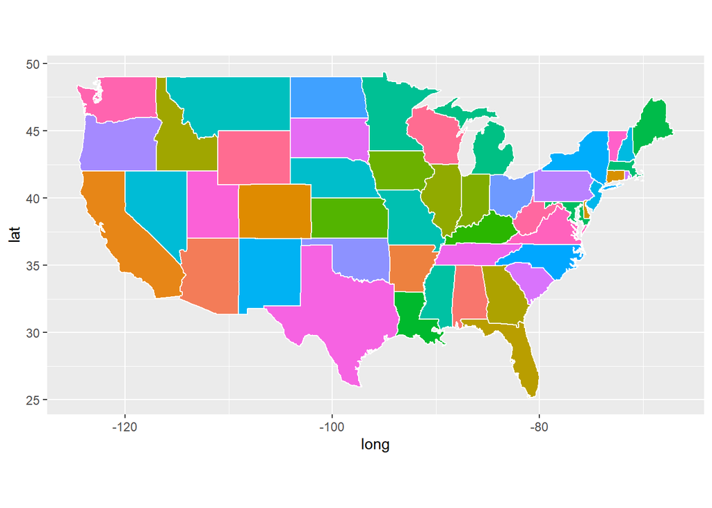

### **6.**

*Use similar code to above to draw county-level map by creating counties = map_data(“county”). Color by county.*

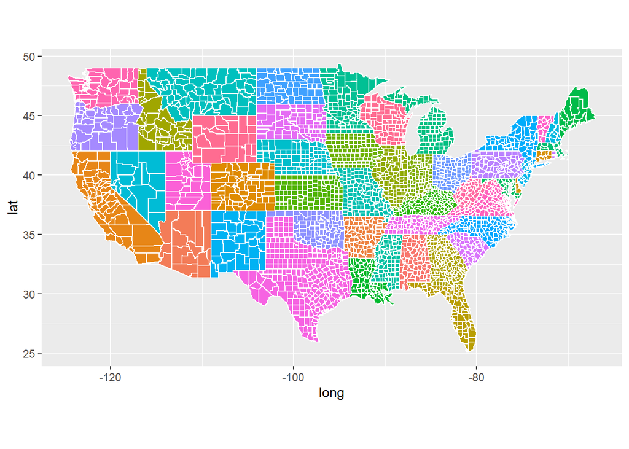

### **7.**

*Now color the map by the winning candidate for each state.*

```r
state.winner$state <- tolower(state.winner$state)
states <- states %>% rename(state = region)
```

Now, perform left_join() on the region and print the new map

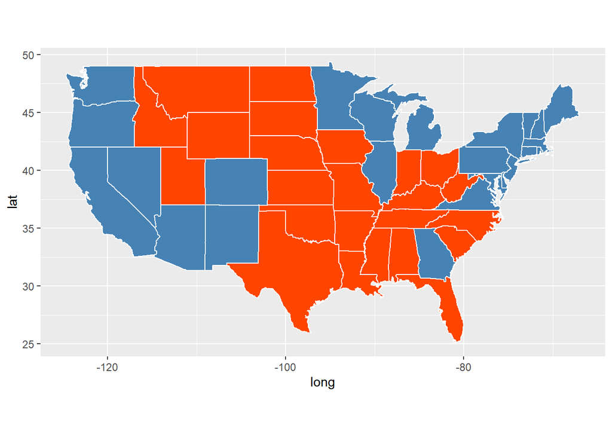

### **8.**

*Color the map of the state of California by the winning candidate for each county. Note that some county have not finished counting the votes, and thus do not have a winner. Leave these counties uncolored.*

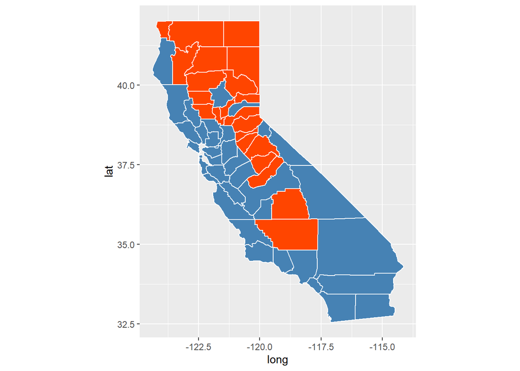

note: The data was behaving oddly when trying to generate this. If I filter ca.counties with state==‘California’, my map generated would be crazy, but there did exist missing regions. However, I figured this would be wrong because we are mapping on region(belong to the counties data), so I changed it to what is seen above. No missing values are present now. It might be a calculation I messed up on previously.

### **9. (Open-Ended)**

*Create a visualization of your choice using census data.*

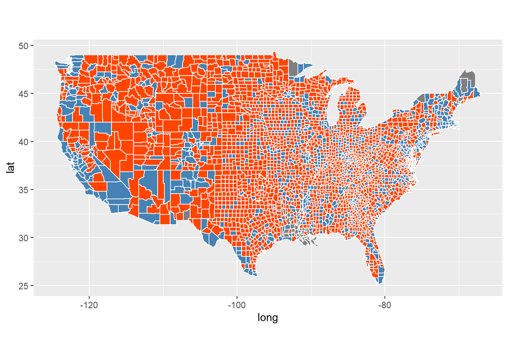

This is a simple map of election results per county on a national scale. Some of the data is missing, and is represented by the color grey. Particularly, Louisiana has a lot of missing counties.

### **10.**

*The census data contains county-level census information. In this problem, we clean and aggregate the information.*

```
## # A tibble: 5 x 27
##   CountyId State   County  TotalPop   Men Women White VotingAgeCitizen Income
##      <dbl> <chr>   <chr>      <dbl> <dbl> <dbl> <dbl>            <dbl>  <dbl>
## 1     1001 Alabama Autauga    55036  48.9  51.1  75.4             74.5  55317
## 2     1003 Alabama Baldwin   203360  48.9  51.1  83.1             76.4  52562
## 3     1005 Alabama Barbour    26201  53.3  46.7  45.7             77.4  33368
## 4     1007 Alabama Bibb       22580  54.3  45.7  74.6             78.2  43404
## 5     1009 Alabama Blount     57667  49.4  50.6  87.4             73.7  47412
## # ... with 18 more variables: Poverty <dbl>, ChildPoverty <dbl>,
## #   Professional <dbl>, Service <dbl>, Office <dbl>, Production <dbl>,
## #   Drive <dbl>, Carpool <dbl>, Transit <dbl>, OtherTransp <dbl>,
## #   WorkAtHome <dbl>, MeanCommute <dbl>, Employed <dbl>, PrivateWork <dbl>,
## #   SelfEmployed <dbl>, FamilyWork <dbl>, Unemployment <dbl>, Minority <dbl>
```

### **11.**

*Run PCA for the cleaned county level census data (with State and County excluded).*

```
##     CountyId        TotalPop             Men            Women
##  Min.   : 1001   Min.   :      74   Min.   :41.90   Min.   :19.17
##  1st Qu.:19033   1st Qu.:   11214   1st Qu.:48.86   1st Qu.:49.47
##  Median :30024   Median :   25848   Median :49.57   Median :50.43
##  Mean   :31394   Mean   :  100768   Mean   :50.04   Mean   :49.96
##  3rd Qu.:46106   3rd Qu.:   66608   3rd Qu.:50.53   3rd Qu.:51.14
##  Max.   :72153   Max.   :10105722   Max.   :80.83   Max.   :58.10
##      White        VotingAgeCitizen     Income          Poverty
##  Min.   :  0.00   Min.   :45.69    Min.   : 11680   Min.   : 2.40
##  1st Qu.: 63.50   1st Qu.:73.22    1st Qu.: 40622   1st Qu.:11.47
##  Median : 83.60   Median :76.04    Median : 47637   Median :15.40
##  Mean   : 74.92   Mean   :75.02    Mean   : 48995   Mean   :16.78
##  3rd Qu.: 92.80   3rd Qu.:78.20    3rd Qu.: 55476   3rd Qu.:19.80
##  Max.   :100.00   Max.   :97.67    Max.   :129588   Max.   :65.20
##   ChildPoverty    Professional      Service          Office
##  Min.   : 0.00   Min.   :11.40   Min.   : 0.00   Min.   : 4.80
##  1st Qu.:14.90   1st Qu.:27.20   1st Qu.:15.80   1st Qu.:19.90
##  Median :21.50   Median :30.50   Median :17.80   Median :22.10
##  Mean   :23.04   Mean   :31.48   Mean   :18.21   Mean   :21.88
##  3rd Qu.:28.60   3rd Qu.:34.90   3rd Qu.:20.20   3rd Qu.:23.90
##  Max.   :83.60   Max.   :69.00   Max.   :46.40   Max.   :37.20
##    Production        Drive          Carpool          Transit
##  Min.   : 0.00   Min.   : 4.60   Min.   : 0.000   Min.   : 0.000
##  1st Qu.:11.50   1st Qu.:77.30   1st Qu.: 8.000   1st Qu.: 0.100
##  Median :15.40   Median :81.00   Median : 9.500   Median : 0.300
##  Mean   :15.84   Mean   :79.63   Mean   : 9.852   Mean   : 0.939
##  3rd Qu.:19.50   3rd Qu.:84.10   3rd Qu.:11.300   3rd Qu.: 0.800
##  Max.   :48.70   Max.   :97.20   Max.   :29.300   Max.   :61.800
##   OtherTransp       WorkAtHome      MeanCommute       Employed
##  Min.   : 0.000   Min.   : 0.000   Min.   : 5.10   Min.   : 59.10
##  1st Qu.: 0.800   1st Qu.: 2.900   1st Qu.:19.60   1st Qu.: 92.00
##  Median : 1.300   Median : 4.100   Median :23.20   Median : 93.90
##  Mean   : 1.599   Mean   : 4.737   Mean   :23.47   Mean   : 93.33
##  3rd Qu.: 1.900   3rd Qu.: 5.800   3rd Qu.:27.00   3rd Qu.: 95.53
##  Max.   :43.200   Max.   :33.000   Max.   :45.10   Max.   :100.00
##   PrivateWork     SelfEmployed      FamilyWork      Unemployment
##  Min.   :31.10   Min.   : 0.000   Min.   :0.0000   Min.   : 0.000
##  1st Qu.:71.20   1st Qu.: 5.200   1st Qu.:0.1000   1st Qu.: 4.475
##  Median :76.10   Median : 6.800   Median :0.2000   Median : 6.100
##  Mean   :74.86   Mean   : 7.773   Mean   :0.2788   Mean   : 6.666
##  3rd Qu.:80.20   3rd Qu.: 9.200   3rd Qu.:0.3000   3rd Qu.: 8.000
##  Max.   :88.80   Max.   :38.000   Max.   :8.0000   Max.   :40.900
##     Minority
##  Min.   :  0.00
##  1st Qu.:  5.60
##  Median : 14.10
##  Mean   : 23.12
##  3rd Qu.: 34.00
##  Max.   :100.00
```

```
##            CountyId            TotalPop                 Men               Women
##    265431836.642843 105299983563.755768            5.836760            5.836760
##               White    VotingAgeCitizen              Income             Poverty
##          531.611404           27.734795    192576080.287494           69.045468
##        ChildPoverty        Professional             Service              Office
##          141.374174           42.561431           14.004872           10.031330
##          Production               Drive             Carpool             Transit
##           33.737315           58.735366            8.779690            9.440695
##         OtherTransp          WorkAtHome         MeanCommute            Employed
##            2.816463            9.446305           32.344713           14.232602
##         PrivateWork        SelfEmployed          FamilyWork        Unemployment
##           58.490612           14.864525            0.200769           14.232602
##            Minority
##          531.233881
```

Some percentages (such as Carpool, Transit, OtherTransp, WorkAtHome, etc) are much smaller on average compared to the averages of other percentage variables. There variances also differ significantly compared to each other. If we didn’t scale the variables before running PCA, then the PCs would be driven with the variables with the greatest mean and variance. Here’s a list of the absolute values of the features for the First Component:

```
##          Poverty     ChildPoverty         Employed     Unemployment
##       0.37643704       0.37120860       0.35750393       0.35750393
##         Minority            White           Income       WorkAtHome
##       0.31161056       0.30852210       0.29268951       0.20253875
##     Professional          Service     SelfEmployed            Drive
##       0.19846314       0.19370610       0.13641873       0.08969803
##           Office      MeanCommute       FamilyWork         CountyId
##       0.08560731       0.08497500       0.07430233       0.06819351
##       Production              Men            Women      PrivateWork
##       0.06088353       0.05588496       0.05588496       0.05387578
##          Carpool      OtherTransp VotingAgeCitizen          Transit
##       0.04887431       0.03375734       0.03281160       0.01185794
##         TotalPop
##       0.00423403
```

*What are the three features with the largest absolute values of the first principal component?* Poverty, ChildPoverty, and Employed have the largest absolute values of PC1. They have the highest correlations with the first component.

```
##          Poverty     ChildPoverty     Unemployment         Minority
##       0.37643704       0.37120860       0.35750393       0.31161056
##          Service            Drive           Office      MeanCommute
##       0.19370610       0.08969803       0.08560731       0.08497500
##         CountyId       Production            Women          Carpool
##       0.06819351       0.06088353       0.05588496       0.04887431
##      OtherTransp         TotalPop          Transit VotingAgeCitizen
##       0.03375734      -0.00423403      -0.01185794      -0.03281160
##      PrivateWork              Men       FamilyWork     SelfEmployed
##      -0.05387578      -0.05588496      -0.07430233      -0.13641873
##     Professional       WorkAtHome           Income            White
##      -0.19846314      -0.20253875      -0.29268951      -0.30852210
##         Employed
##      -0.35750393
```

*Which features have opposite signs and what does that mean about the correlation between these features?*

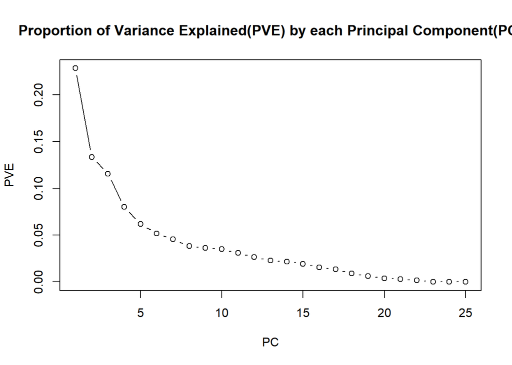

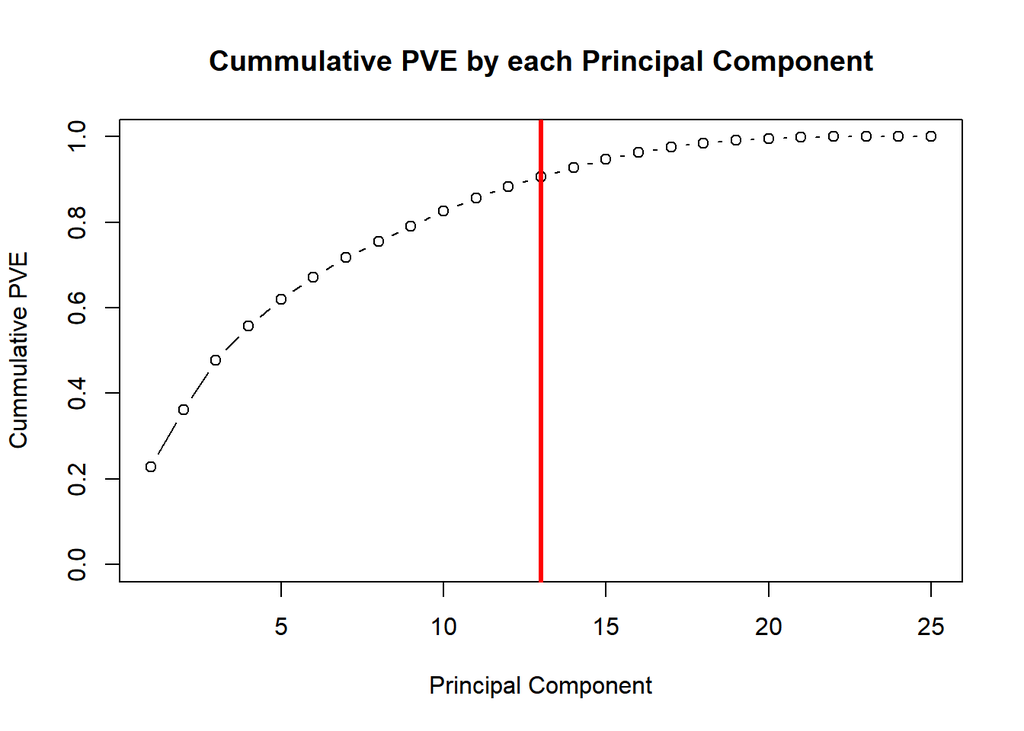

```r
census.clean.id
```

```
## # A tibble: 3,220 x 25
##    CountyId TotalPop   Men Women White VotingAgeCitizen Income Poverty
##       <dbl>    <dbl> <dbl> <dbl> <dbl>            <dbl>  <dbl>   <dbl>
##  1     1001    55036  48.9  51.1  75.4             74.5  55317    13.7
##  2     1003   203360  48.9  51.1  83.1             76.4  52562    11.8
##  3     1005    26201  53.3  46.7  45.7             77.4  33368    27.2
##  4     1007    22580  54.3  45.7  74.6             78.2  43404    15.2
##  5     1009    57667  49.4  50.6  87.4             73.7  47412    15.6
##  6     1011    10478  53.6  46.4  21.6             78.4  29655    28.5
##  7     1013    20126  46.8  53.2  52.2             76.8  36326    24.4
##  8     1015   115527  48.1  51.9  72.7             76.5  43686    18.6
##  9     1017    33895  48.1  51.9  56.2             77.5  37342    18.8
## 10     1019    25855  49.7  50.3  91.8             79.8  40041    16.1
## # ... with 3,210 more rows, and 17 more variables: ChildPoverty <dbl>,
## #   Professional <dbl>, Service <dbl>, Office <dbl>, Production <dbl>,
## #   Drive <dbl>, Carpool <dbl>, Transit <dbl>, OtherTransp <dbl>,
## #   WorkAtHome <dbl>, MeanCommute <dbl>, Employed <dbl>, PrivateWork <dbl>,
## #   SelfEmployed <dbl>, FamilyWork <dbl>, Unemployment <dbl>, Minority <dbl>
```

### **13.**

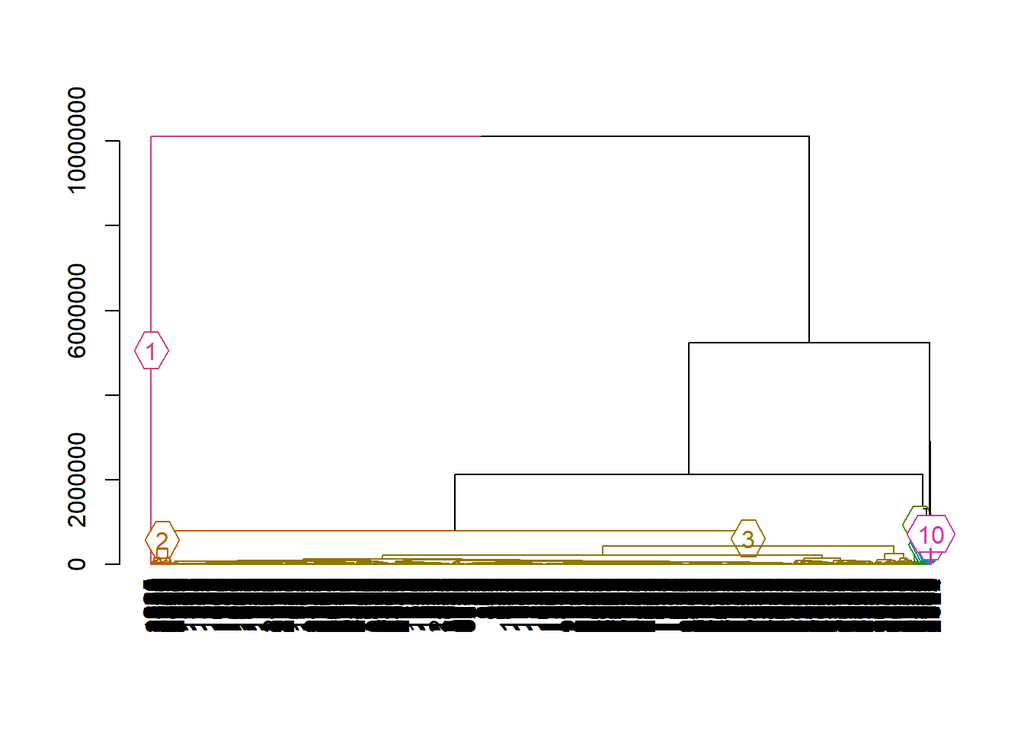

```r
census.clustinfo <- census.clean
census.clustinfo['cluster_10_norm'] <- cutree(cens.hclust, 10)
```

This is an obvious comment, but a dendrogram will just not be legible with this data. There’s thousands of counties, meaning thousands of ends. If we want to better observe how the clustering algorithm performed, we should see how it performs by observing what counties are clustered together

```r
#Get ID of Santa Barbara County to for comparisons
SB.id = census.clean %>% filter(County == 'Santa Barbara') %>% select(CountyId)
SB.id=SB.id[[1,1]]
SB.id
```

```
## [1] 6083
```

```r
cens.hclust$dist.method
```

```
## [1] "euclidean"
```

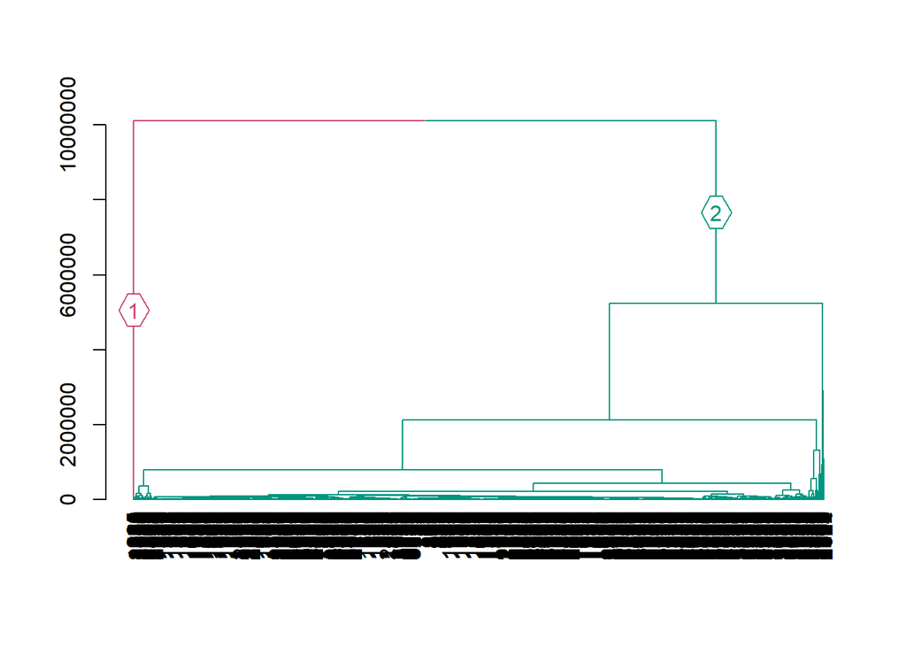

```r
#Clustering with normal parameters, 2 CLUSTERS
#Plot the dendograms
dend2 = as.dendrogram(cens.hclust)
dend2 = color_branches(dend2, k=2, groupLabels = T)
plot(dend2)
```

```r
#Add new column to our copy of clustering info
census.clustinfo['cluster_2_norm'] <- cutree(cens.hclust, 2)
```

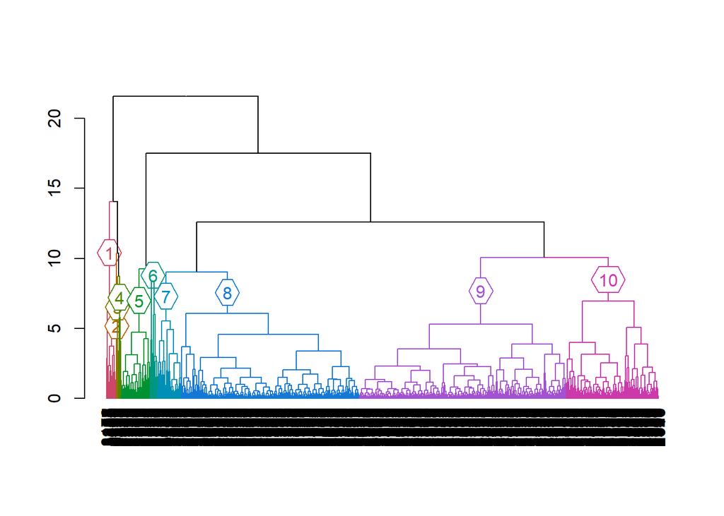

```r
#Rerun clustering, replacing original features with pc1 & pc2


#calculate the euclidean distance matrix
pcs.dist = dist(pcs.1_2)

#Run hierarchical clustering using complete linkage
pcs.hclust <- hclust(pcs.dist)

#Plot the dendograms
dend.pc.1 = as.dendrogram(pcs.hclust)
dend.pc.1 = color_branches(dend.pc.1, k=10,groupLabels=T)
plot(dend.pc.1)
```

```r
#Add new column to our copy of clustering info
census.clustinfo['cluster_10_pc'] <- cutree(pcs.hclust, 10)
```

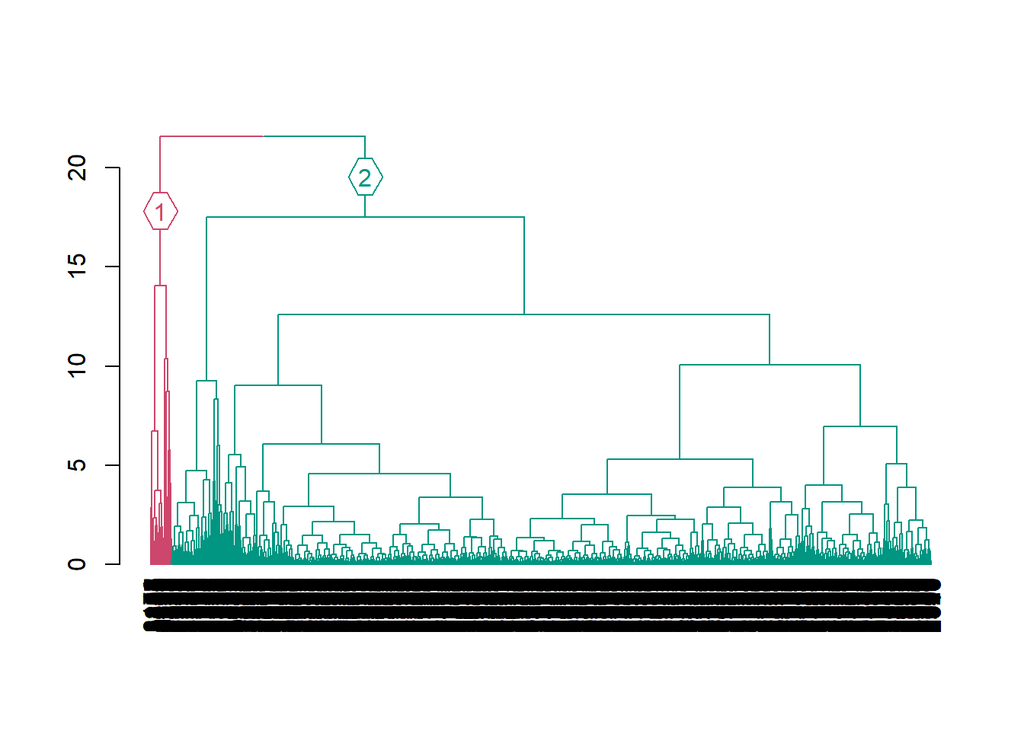

```r
#Rerun clustering, replacing original features with pc1 & pc2 USING 2 clusters


#Plot the dendograms
dend.pc.2 = as.dendrogram(pcs.hclust)
dend.pc.2 = color_branches(dend.pc.2, k=2,groupLabels=T)
plot(dend.pc.2)
```

```r
#Add new column to our copy of clustering info
census.clustinfo['cluster_2_pc'] <- cutree(pcs.hclust, 2)
```

*OBSERVATIONS*

```r
census.clustinfo[census.clustinfo$CountyId == '6083',]
```

```
## # A tibble: 1 x 31
##   CountyId State      County  TotalPop   Men Women White VotingAgeCitizen Income
##      <dbl> <chr>      <chr>      <dbl> <dbl> <dbl> <dbl>            <dbl>  <dbl>
## 1     6083 California Santa ~   442996  50.1  49.9  45.3             63.4  68023
## # ... with 22 more variables: Poverty <dbl>, ChildPoverty <dbl>,
## #   Professional <dbl>, Service <dbl>, Office <dbl>, Production <dbl>,
## #   Drive <dbl>, Carpool <dbl>, Transit <dbl>, OtherTransp <dbl>,
## #   WorkAtHome <dbl>, MeanCommute <dbl>, Employed <dbl>, PrivateWork <dbl>,
## #   SelfEmployed <dbl>, FamilyWork <dbl>, Unemployment <dbl>, Minority <dbl>,
## #   cluster_10_norm <int>, cluster_2_norm <int>, cluster_10_pc <int>,
## #   cluster_2_pc <int>
```

```r
#Second cluster, 10 total, normal parameters
census.clustinfo[census.clustinfo$cluster_10_norm == '2',]
```

```
## # A tibble: 87 x 31
##    CountyId State      County TotalPop   Men Women White VotingAgeCitizen Income
##       <dbl> <chr>      <chr>     <dbl> <dbl> <dbl> <dbl>            <dbl>  <dbl>
##  1     1073 Alabama    Jeffe~   659460  47.4  52.6  50.4             74.5  49321
##  2     6053 California Monte~   433168  51.0  49.0  30.6             53.5  63249
##  3     6077 California San J~   724153  49.7  50.3  33.2             61.1  57813
##  4     6081 California San M~   763450  49.3  50.7  39.9             64.8 105667
##  5     6083 California Santa~   442996  50.1  49.9  45.3             63.4  68023
##  6     6095 California Solano   434981  49.7  50.3  39               69.5  72950
##  7     6097 California Sonoma   500943  49.0  51.0  63.8             70.9  71769
##  8     6099 California Stani~   535684  49.4  50.6  43.4             61.8  54260
##  9     6107 California Tulare   458809  50.0  50.0  29.5             54.4  44871
## 10     8001 Colorado   Adams    487850  50.4  49.6  51.1             62.8  64087
## # ... with 77 more rows, and 22 more variables: Poverty <dbl>,
## #   ChildPoverty <dbl>, Professional <dbl>, Service <dbl>, Office <dbl>,
## #   Production <dbl>, Drive <dbl>, Carpool <dbl>, Transit <dbl>,
## #   OtherTransp <dbl>, WorkAtHome <dbl>, MeanCommute <dbl>, Employed <dbl>,
## #   PrivateWork <dbl>, SelfEmployed <dbl>, FamilyWork <dbl>,
## #   Unemployment <dbl>, Minority <dbl>, cluster_10_norm <int>,
## #   cluster_2_norm <int>, cluster_10_pc <int>, cluster_2_pc <int>
```

```r
#first cluster, 2 total, normal parameters
census.clustinfo[census.clustinfo$cluster_2_norm == '1',]
```

```
## # A tibble: 3,219 x 31
##    CountyId State   County   TotalPop   Men Women White VotingAgeCitizen Income
##       <dbl> <chr>   <chr>       <dbl> <dbl> <dbl> <dbl>            <dbl>  <dbl>
##  1     1001 Alabama Autauga     55036  48.9  51.1  75.4             74.5  55317
##  2     1003 Alabama Baldwin    203360  48.9  51.1  83.1             76.4  52562
##  3     1005 Alabama Barbour     26201  53.3  46.7  45.7             77.4  33368
##  4     1007 Alabama Bibb        22580  54.3  45.7  74.6             78.2  43404
##  5     1009 Alabama Blount      57667  49.4  50.6  87.4             73.7  47412
##  6     1011 Alabama Bullock     10478  53.6  46.4  21.6             78.4  29655
##  7     1013 Alabama Butler      20126  46.8  53.2  52.2             76.8  36326
##  8     1015 Alabama Calhoun    115527  48.1  51.9  72.7             76.5  43686
##  9     1017 Alabama Chambers    33895  48.1  51.9  56.2             77.5  37342
## 10     1019 Alabama Cherokee    25855  49.7  50.3  91.8             79.8  40041
## # ... with 3,209 more rows, and 22 more variables: Poverty <dbl>,
## #   ChildPoverty <dbl>, Professional <dbl>, Service <dbl>, Office <dbl>,
## #   Production <dbl>, Drive <dbl>, Carpool <dbl>, Transit <dbl>,
## #   OtherTransp <dbl>, WorkAtHome <dbl>, MeanCommute <dbl>, Employed <dbl>,
## #   PrivateWork <dbl>, SelfEmployed <dbl>, FamilyWork <dbl>,
## #   Unemployment <dbl>, Minority <dbl>, cluster_10_norm <int>,
## #   cluster_2_norm <int>, cluster_10_pc <int>, cluster_2_pc <int>
```

```r
#Second cluster, normal parameters
census.clustinfo[census.clustinfo$cluster_10_pc == '2',]
```

```
## # A tibble: 140 x 31
##    CountyId State   County  TotalPop   Men Women White VotingAgeCitizen Income
##       <dbl> <chr>   <chr>      <dbl> <dbl> <dbl> <dbl>            <dbl>  <dbl>
##  1     1005 Alabama Barbour    26201  53.3  46.7  45.7             77.4  33368
##  2     1011 Alabama Bullock    10478  53.6  46.4  21.6             78.4  29655
##  3     1047 Alabama Dallas     40755  46.2  53.8  27.7             74.4  30065
##  4     1063 Alabama Greene      8533  47.6  52.4  17.1             76.6  20954
##  5     1085 Alabama Lowndes    10362  47.2  52.8  24.3             76.9  29785
##  6     1087 Alabama Macon      19358  46.1  53.9  15.5             81.4  32308
##  7     1099 Alabama Monroe     21745  47.6  52.4  54.5             76.6  26036
##  8     1105 Alabama Perry       9680  47.8  52.2  29.4             77.4  22973
##  9     1119 Alabama Sumter     13084  46.1  53.9  24.6             78.1  21663
## 10     1131 Alabama Wilcox     10919  46.7  53.3  26.9             75.3  27012
## # ... with 130 more rows, and 22 more variables: Poverty <dbl>,
## #   ChildPoverty <dbl>, Professional <dbl>, Service <dbl>, Office <dbl>,
## #   Production <dbl>, Drive <dbl>, Carpool <dbl>, Transit <dbl>,
## #   OtherTransp <dbl>, WorkAtHome <dbl>, MeanCommute <dbl>, Employed <dbl>,
## #   PrivateWork <dbl>, SelfEmployed <dbl>, FamilyWork <dbl>,
## #   Unemployment <dbl>, Minority <dbl>, cluster_10_norm <int>,
## #   cluster_2_norm <int>, cluster_10_pc <int>, cluster_2_pc <int>
```

```r
#First Cluster, normal parameters
census.clustinfo[census.clustinfo$cluster_2_pc == '1',]
```

```
## # A tibble: 3,135 x 31
##    CountyId State   County   TotalPop   Men Women White VotingAgeCitizen Income
##       <dbl> <chr>   <chr>       <dbl> <dbl> <dbl> <dbl>            <dbl>  <dbl>
##  1     1001 Alabama Autauga     55036  48.9  51.1  75.4             74.5  55317
##  2     1003 Alabama Baldwin    203360  48.9  51.1  83.1             76.4  52562
##  3     1005 Alabama Barbour     26201  53.3  46.7  45.7             77.4  33368
##  4     1007 Alabama Bibb        22580  54.3  45.7  74.6             78.2  43404
##  5     1009 Alabama Blount      57667  49.4  50.6  87.4             73.7  47412
##  6     1011 Alabama Bullock     10478  53.6  46.4  21.6             78.4  29655
##  7     1013 Alabama Butler      20126  46.8  53.2  52.2             76.8  36326
##  8     1015 Alabama Calhoun    115527  48.1  51.9  72.7             76.5  43686
##  9     1017 Alabama Chambers    33895  48.1  51.9  56.2             77.5  37342
## 10     1019 Alabama Cherokee    25855  49.7  50.3  91.8             79.8  40041
## # ... with 3,125 more rows, and 22 more variables: Poverty <dbl>,
## #   ChildPoverty <dbl>, Professional <dbl>, Service <dbl>, Office <dbl>,
## #   Production <dbl>, Drive <dbl>, Carpool <dbl>, Transit <dbl>,
## #   OtherTransp <dbl>, WorkAtHome <dbl>, MeanCommute <dbl>, Employed <dbl>,
## #   PrivateWork <dbl>, SelfEmployed <dbl>, FamilyWork <dbl>,
## #   Unemployment <dbl>, Minority <dbl>, cluster_10_norm <int>,
## #   cluster_2_norm <int>, cluster_10_pc <int>, cluster_2_pc <int>
```

## **CLASSIFICATION**

We are now working with supervised learning tasks. Our most important question will be: Can we use census information in a county to predict the winner in that county?

We first need to combine county.winner and census.clean. For simplicity, the following code is given/makes the chances to merge them into election.cl for classification.

```r
# we move all state and county names into lower-case
tmpwinner <- county.winner %>% ungroup %>%
  mutate_at(vars(state, county), tolower)

# we move all state and county names into lower-case
# we further remove suffixes of "county" and "parish"
tmpcensus <- census.clean %>% mutate_at(vars(State, County), tolower) %>%
  mutate(County = gsub(" county|  parish", "", County))

# we join the two datasets
election.cl <- tmpwinner %>%
  left_join(tmpcensus, by = c("state"="State", "county"="County")) %>%
  na.omit

# drop levels of county winners if you haven't done so in previous parts
election.cl$candidate <- droplevels(election.cl$candidate)


## save meta information
election.meta <- election.cl %>% select(c(county, party, CountyId, state, votes, pct, total))

## save predictors and class labels
election.cl = election.cl %>% select(-c(county, party, CountyId, state, votes, pct, total))
```

### **14.**

*Understand the code above. Why do we need to exclude the predictor party from election.cl?* Essentially, Party and candidate are the same variables. The republican candidate is Donald Trump, the democrat candidate is Joe Biden. It’d have the greatest correlation and would render our other variables useless. We’re not interested in the behavior between Party and candidate. We want to know what information about US counties best determined their choice of candidate.

We’ll now split election.cl into a training and test data-set.

```r
set.seed(10)
n <- nrow(election.cl)
idx.tr <- sample.int(n, 0.8*n)
election.tr <- election.cl[idx.tr, ]
election.te <- election.cl[-idx.tr, ]
```

And we’ll perform 10-fold Cross Validation.

```r
set.seed(20)
nfold <- 10
folds <- sample(cut(1:nrow(election.tr), breaks=nfold, labels=FALSE))
```

Later on, we’ll also need the following error rate function. The object records will be used to record the performance of our different methods.

```r
calc_error_rate = function(predicted.value, true.value){
  return(mean(true.value!=predicted.value))
}
records = matrix(NA, nrow=3, ncol=2)
colnames(records) = c("train.error","test.error")
rownames(records) = c("tree","logistic","lasso")
```

## **CLASSIFICATION**

### **15.**

*Decision tree: train a decision tree by `cv.tree()`*

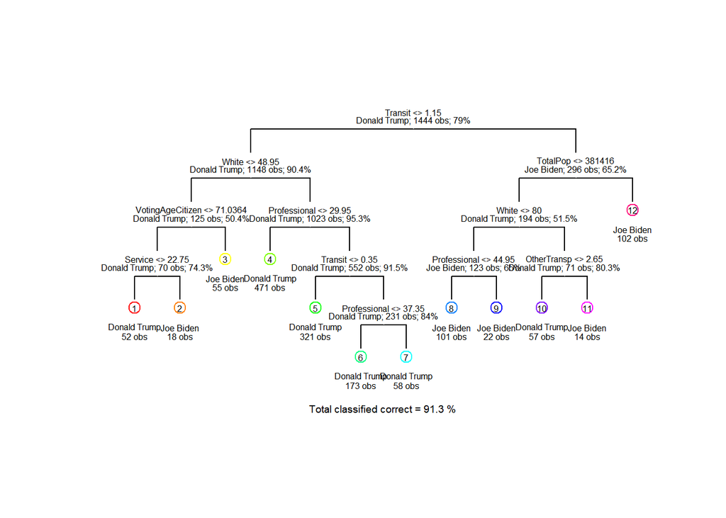

Decision Tree before pruning

The Pre-pruned decision Tree splits the data at Transit first. We can calculate the error rate of the pre-pruned tree using the given code.

```
## [1] "Test Error Rate: 0.334487534626039"
```

```
## [1] "Train Error Rate: 0"
```

```r
set.seed(20)
cv = cv.tree(elect.tree, FUN=prune.misclass, rand=folds)
best.cv = min(cv$size[cv$dev == min(cv$dev)])
best.cv
```

```
## [1] 7
```

The tree with 7 terminal nodes generates the lower error rate, so we will use that for pruning

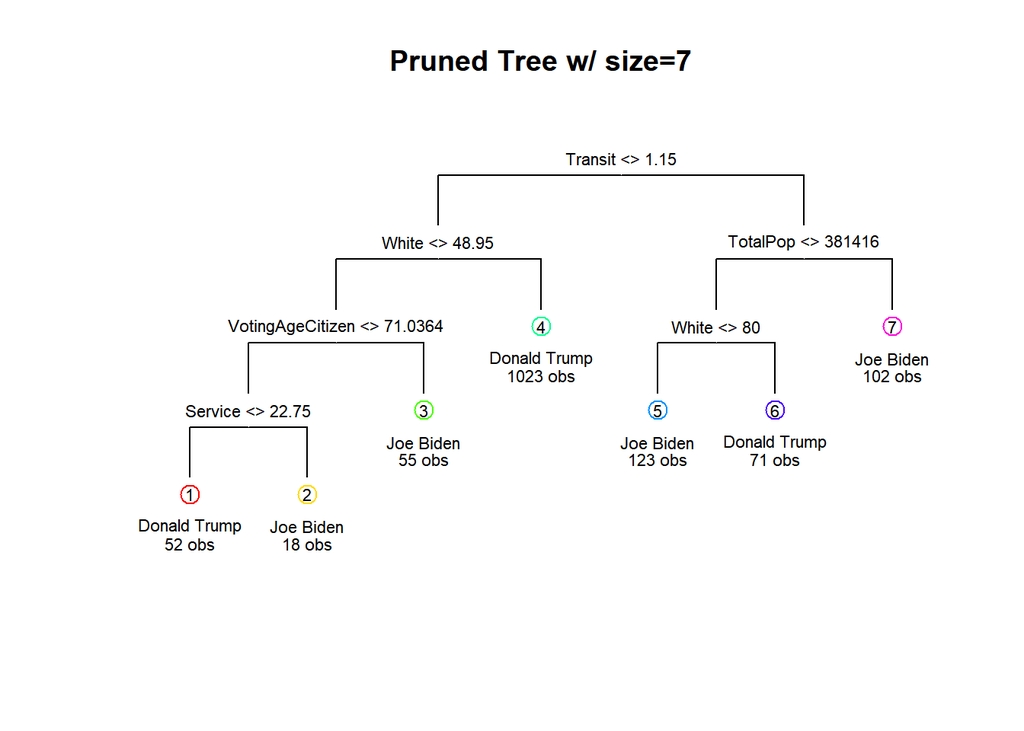

```
## integer(0)
```

```r
elect.pt <- prune.misclass ( elect.tree, best=best.cv)

draw.tree(elect.pt, cex=.7) +
  title('Pruned Tree w/ size=7')
```

From the Pruned Tree shown above (and the Pre-Pruned Tree beforehand), “Transit” is split first. This may seem odd, but it likely has to do with its correlation with TotalPop. Public transit is much more common in cities, and cities contribute to high population in a county. From the graph, it appears that cities with a greater percentage of white people tend to have voted for Donald Trump, whereas cities with a lesser percentage of white people, meaning a higher percentage of minorities, voted for Joe Biden. Donald Trump had greatest success in counties with a lower percentage of transit use and higher percentage of white people. This would be rural counties with smaller cities. Rural, white voters overwhelmingly voted for Donald Trump, as we’ve seen from our visualizations and here.

Now we can predict on the test set and calculate our error rate and record them in our table

```
##          train.error test.error
## tree      0.08933518  0.1301939
## logistic          NA         NA
## lasso             NA         NA
```

We generate a training error rate of ~9% and a test error rate of ~13% through decision tree classification. This is a fairly good number, but we may yield better results through either the logistic or lasso methods.

### **16.**

*Let’s run a logistic regression to predict the winning candidate in each county.* *“Well I believe I’ll vote for a third party candidate!”* *“Go ahead, throw your vote away! Ahahaha!”* While the United States is not de jure a two party system, it is in practice. Fortunately, this allows us to create a logistic regression classification model.

```r
elect.glm <- glm(candidate~.,data=election.tr, family=binomial)
summary(elect.glm)
```

```
##
## Call:
## glm(formula = candidate ~ ., family = binomial, data = election.tr)
##
## Deviance Residuals:
##     Min       1Q   Median       3Q      Max
## -4.2961  -0.2824  -0.1190  -0.0330   3.2130
##
## Coefficients: (2 not defined because of singularities)
##                       Estimate    Std. Error z value       Pr(>|z|)
## (Intercept)       1.7561883884 11.8250382270   0.149       0.881937
## TotalPop          0.0000019382  0.0000007189   2.696       0.007014 **
## Men              -0.0976400054  0.0543664563  -1.796       0.072501 .
## Women                       NA            NA      NA             NA
## White            -0.1964060151  0.0801604725  -2.450       0.014279 *
## VotingAgeCitizen  0.1646646614  0.0293289047   5.614 0.000000019723 ***
## Income            0.0000244127  0.0000192043   1.271       0.203653
## Poverty           0.0688755161  0.0500018792   1.377       0.168371
## ChildPoverty     -0.0562503383  0.0297656722  -1.890       0.058788 .
## Professional      0.3088061934  0.0487151054   6.339 0.000000000231 ***
## Service           0.2983969737  0.0570902130   5.227 0.000000172504 ***
## Office            0.1306938031  0.0591381757   2.210       0.027107 *
## Production        0.2204356769  0.0507054736   4.347 0.000013777693 ***
## Drive            -0.2600525848  0.0538165846  -4.832 0.000001350314 ***
## Carpool          -0.2335282760  0.0705895467  -3.308       0.000939 ***
## Transit           0.0859583137  0.1152724357   0.746       0.455850
## OtherTransp       0.0195318581  0.1077389660   0.181       0.856141
## WorkAtHome       -0.1571081545  0.0817617866  -1.922       0.054664 .
## MeanCommute      -0.0132147385  0.0298459447  -0.443       0.657936
## Employed         -0.0418630248  0.0457400788  -0.915       0.360067
## PrivateWork       0.1195112422  0.0268513285   4.451 0.000008553097 ***
## SelfEmployed      0.0231475607  0.0567424121   0.408       0.683317
## FamilyWork       -0.2475604690  0.3172656902  -0.780       0.435218
## Unemployment                NA            NA      NA             NA
## Minority         -0.0656289723  0.0771971834  -0.850       0.395243
## ---
## Signif. codes:  0 '***' 0.001 '**' 0.01 '*' 0.05 '.' 0.1 ' ' 1
##
## (Dispersion parameter for binomial family taken to be 1)
##
##     Null deviance: 1483.7  on 1443  degrees of freedom
## Residual deviance:  562.4  on 1421  degrees of freedom
## AIC: 608.4
##
## Number of Fisher Scoring iterations: 7
```

Professional, VotingAgeCitizen and Service appear to have the greatest positive impact on the response. White, Drive, Carpool, and FamilyWork had the greatest negative impact. Our decision Tree had roughly the same variables as our logistic model. Before we can make predictions, we need to calculate the best threshold value to use. The “best” value would be the minimum euclidean distance from (FPR, FNR) to (0,0). Basically, we want the value that yields the lower FPR and FNR.

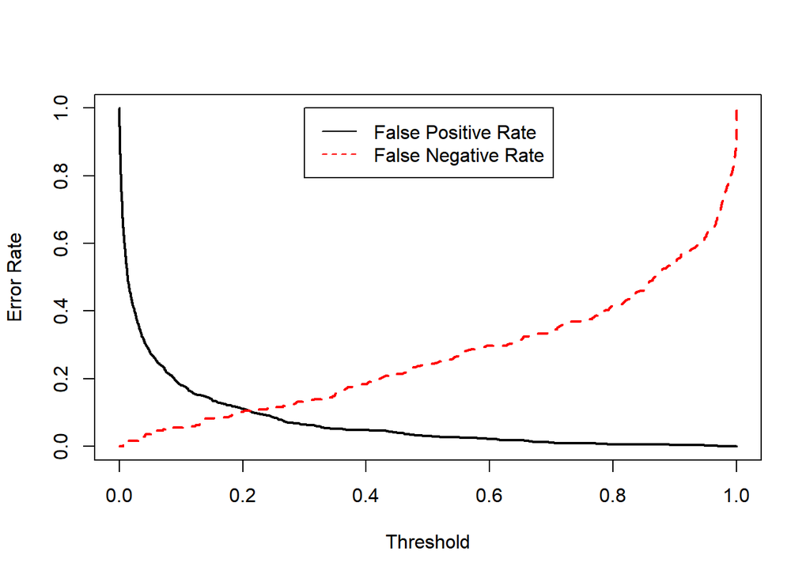

Above is the FPR and FNR versus Threshold values, giving us a rough idea on what we can expect the threshold to be.

```r
rate = as.data.frame(cbind(Cutoff=cutoff,FPR=fpr,FNR=fnr))
rate$distance = sqrt((rate[,2]^2+rate[,3]^2))
threshold = rate$Cutoff[which.min(rate$distance)]

filter(rate, distance==min(distance))
```

```
##        Cutoff        FPR       FNR distance
## 913 0.2777778 0.06923751 0.1188119 0.137514
```

With a Cutoff of .2778, we generate the smallest Euclidean distance. This will be our threshold. Now we can compute the error rates and record them.

```
##          train.error test.error
## tree      0.08933518 0.13019391
## logistic  0.08033241 0.09418283
## lasso             NA         NA
```

Compared to the Tree Model, the training error rate is relative the same at 8%, but the test error rate is only 9.5%, a significant improvement.

Finally, we should compare these results to a lasso model.

**17.** *You may notice that you get a warning `glm.fit: fitted probabilities numerically 0 or 1 occurred` This is usually a sign that we are overfitting. One way to control overfitting in logistic regression is through regularization.*

We’ll use the cv.glmnet function to perform a 10-fold cross validation and choose the best regularization parameter for the logistic regression with the LASSO penalty.

```r
x <- as.matrix( select(election.tr, -candidate) )
y <- election.tr$candidate
set.seed(10)

cv.out = cv.glmnet(x, y, alpha=1, lambda=seq(1,50)*1e-4, family=binomial)

bestlam = cv.out$lambda.min
bestlam
```

```
## [1] 0.001
```

```r
out = glmnet(x,y, alpha=0, family=binomial)

coefficients <- predict(out, type='coefficients', s=bestlam)
coefficients
```

```
## 25 x 1 sparse Matrix of class "dgCMatrix"
##                                1
## (Intercept)      -6.372411886523
## TotalPop          0.000001370135
## Men              -0.044940216456
## Women             0.045016082738
## White            -0.035689084010
## VotingAgeCitizen  0.075242014965
## Income            0.000021411252
## Poverty           0.031391645610
## ChildPoverty     -0.010927854987
## Professional      0.114696298520
## Service           0.100959760327
## Office            0.012078483247
## Production        0.009732536005
## Drive            -0.078598831006
## Carpool          -0.073298803906
## Transit           0.126542538958
## OtherTransp       0.144029688538
## WorkAtHome        0.006552522192
## MeanCommute      -0.014766333357
## Employed         -0.034879712299
## PrivateWork       0.048063276139
## SelfEmployed     -0.073939962749
## FamilyWork       -0.227391637716
## Unemployment      0.035289686508
## Minority          0.033103614758
```

In the Lasso model, FamilyWork is the strongest coefficient, followed by OtherTransp, Transit, Professional, and Service. These all fall in line with what we’ve observed from our past models Finally, we need to compute the test and train error rates.

```r
x.tr <- as.matrix(select(election.tr,-candidate))
y.tr <- as.matrix(select(election.tr,candidate))
y.tr <-ifelse(y.tr=="Joe Biden", 1,0)

#Lasso model, with best lambda
elect.lasso <- glmnet(x.tr, y.tr, alpha=1, lambda=bestlam, family=binomial)
#

#predict on train
lasso.tr <- predict(elect.lasso, newx=x.tr, type='response')
lasso.tr.class <- ifelse(lasso.tr >0.5, "Joe Biden", "Donald Trump")

#Predict on Test
x.te <- as.matrix(select(election.te, - candidate))
y.te <- as.matrix(select(election.te, candidate))
y.te <- ifelse(y.te == "Joe Biden", 1,0)
lasso.te <- predict(elect.lasso, newx = x.te, type='response')
lasso.te.class <- ifelse(lasso.te >0.5, "Joe Biden", "Donald Trump")

#Test/Train Error Rates
lasso.tr.err <- calc_error_rate(lasso.tr.class,election.tr$candidate)
lasso.te.err <- calc_error_rate(lasso.te.class, election.te$candidate)

paste("Lasso Model - Train Error Rate: ",lasso.tr.err)
```

```
## [1] "Lasso Model - Train Error Rate:  0.0775623268698061"
```

```r
paste("Lasso Model - Test Error Rate: ",lasso.te.err)
```

```
## [1] "Lasso Model - Test Error Rate:  0.0858725761772853"
```

```r
records[3,1] <- lasso.te.err
records[3,2] <- lasso.tr.err

# # TEST CODE FOR LATER
# #pred = prediction(lasso.predtr,s=bestlam,type='response')
#
# lasso.pred.train = predict(elect.lasso, s=bestlam, newx = x,family='binomial',type='response')
```

We get a test error rate of 8.6% for our lasso model. That’s pretty good! Let’s now check out our error rates for all of our models, now.

```r
records
```

[output not shown]

**18.** *Compute ROC curves for the decision tree, logistic regression and LASSO logistic regression using predictions on the test data.*

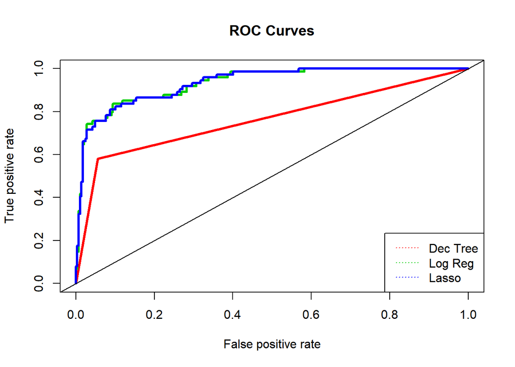

```r
#Perform Predictions on testing data for each model
pred.tree <- prediction(as.numeric(elect.pt.predte), as.numeric(election.te$candidate))
pred.log <- prediction(as.numeric(glm.pred.te), as.numeric(election.te$candidate))
pred.lasso <- prediction(as.numeric(lasso.te), as.numeric(election.te$candidate))
#Compute Performances for each model
perf.tree <- performance(pred.tree, measure = 'tpr', x.measure = 'fpr')
perf.log <- performance(pred.log, measure='tpr', x.measure='fpr')
perf.lasso <- performance(pred.lasso, measure='tpr', x.measure='fpr')

#Plot ROC curves for each model

plot(perf.tree, col=2, lwd=3, main="ROC Curves")
plot(perf.log, add=TRUE, col=3, lwd=3)
plot(perf.lasso,add=TRUE,col=4,lwd=3)
abline(0,1)
legend('bottomright',legend=c("Dec Tree","Log Reg", "Lasso"), col=c(2,3,4), lty=3)
```

## Taking it Further

### **19.**

*Explore additional classification methods.*

Let’s take a dive into Random Forests and see how it compares with our other methods.

```r
mtry = tuneRF(election.cl[,-1], election.cl$candidate)
```

```
## mtry = 4  OOB error = 8.25%
## Searching left ...
## mtry = 2     OOB error = 8.81%
## -0.06711409 0.05
## Searching right ...
## mtry = 8     OOB error = 8.37%
## -0.01342282 0.05
```

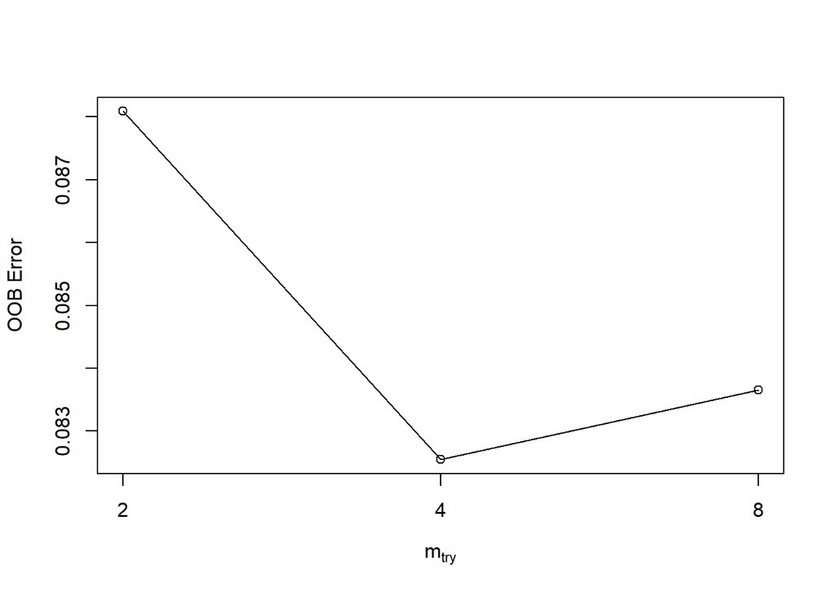

```r
elect.rf <- randomForest(candidate~.,data=election.tr,importance=TRUE,mtry = mtry )


elect.rf
```

```
##
## Call:
##  randomForest(formula = candidate ~ ., data = election.tr, importance = TRUE,      mtry = mtry)
##                Type of random forest: classification
##                      Number of trees: 500
## No. of variables tried at each split: 1
##
##         OOB estimate of  error rate: 8.86%
## Confusion matrix:
##              Donald Trump Joe Biden class.error
## Donald Trump         1121        20  0.01752848
## Joe Biden             108       195  0.35643564
```

```r
importance(elect.rf)
```

```
##                  Donald Trump Joe Biden MeanDecreaseAccuracy MeanDecreaseGini
## TotalPop            16.099724 19.751853            23.328643        35.170114
## Men                  7.034586 10.405924            10.721852        16.961276
## Women                6.999534  8.838397            10.359381        17.319074
## White               14.253845 21.621009            21.731256        33.536553
## VotingAgeCitizen     7.357000  8.786134            12.016360        16.445442
## Income              11.218596 12.065256            16.692800        21.586432
## Poverty              9.044227  8.857367            12.844682        16.359831
## ChildPoverty         8.388016 11.368817            13.709430        17.253290
## Professional        13.430376 18.374570            20.406264        27.419444
## Service             10.147956  7.150321            12.235895        13.435900
## Office               3.263053  7.541293             7.555078        13.114306
## Production           7.434086 15.247896            16.070567        23.384925
## Drive               13.921216 12.025920            17.777513        18.351147
## Carpool              4.367876  3.404246             5.710321        12.206813
## Transit             16.972580 22.744658            24.756222        43.814324
## OtherTransp          3.298999 12.856518            10.960468        15.177146
## WorkAtHome           6.628442  8.910991            11.079749        13.249086
## MeanCommute          4.844916  6.011950             7.589347        13.192328
## Employed             7.992293 11.476332            13.339042        15.450404
## PrivateWork          9.988910  6.108204            11.460941        14.660717
## SelfEmployed         8.571009 14.327967            15.847737        19.065048
## FamilyWork          -2.839159 10.468199             5.852559         9.937616
## Unemployment         9.825070 12.931883            14.787702        15.998977
## Minority            15.215664 19.505543            21.332627        31.425232
```

Let’s make a boosted model as well. For a boosted model, we will set Joe Biden to be 1, and Donald Trump to be 0. We’ll want 1000 bagged trees and set the interaction depth to be just 2. We’ll leave the shrinkage parameter to its default of 0.001.

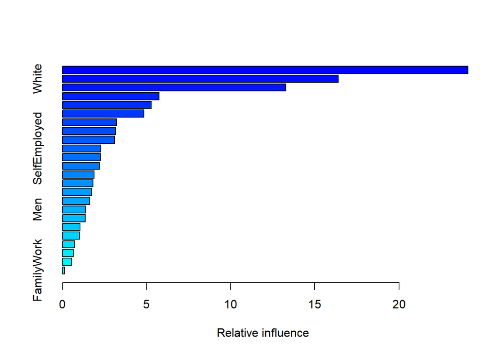

```
##                               var    rel.inf
## Transit                   Transit 24.1012224
## White                       White 16.4027796
## TotalPop                 TotalPop 13.2850692
## Professional         Professional  5.7577772
## VotingAgeCitizen VotingAgeCitizen  5.2916882
## Minority                 Minority  4.8555089
## Service                   Service  3.2469983
## ChildPoverty         ChildPoverty  3.1713833
## Income                     Income  3.0988687
## SelfEmployed         SelfEmployed  2.2907002
## OtherTransp           OtherTransp  2.2710389
## Production             Production  2.2144958
## Drive                       Drive  1.8980876
## PrivateWork           PrivateWork  1.8375008
## Office                     Office  1.7332812
## MeanCommute           MeanCommute  1.6240847
## Men                           Men  1.3923076
## Unemployment         Unemployment  1.3756882
## Poverty                   Poverty  1.0548555
## WorkAtHome             WorkAtHome  1.0188857
## Women                       Women  0.7219256
## Carpool                   Carpool  0.6595988
## Employed                 Employed  0.5594182
## FamilyWork             FamilyWork  0.1368354
```

```r
set.seed(27)
elect.boost <- gbm(ifelse(candidate=="Joe Biden", 1,0)~.,data=election.tr,
                   distribution='bernoulli',n.trees=1000,interaction.depth=2)
summary(elect.boost)
```

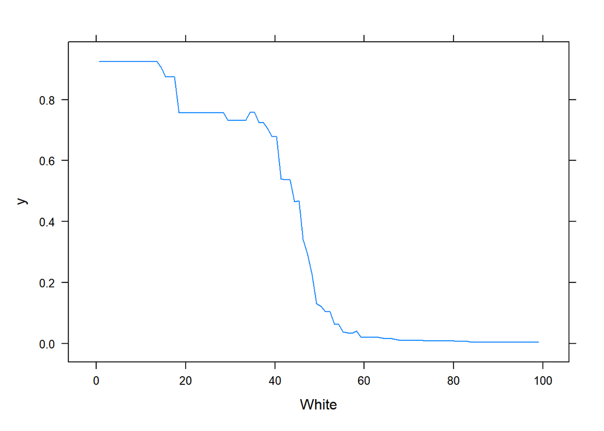

```r
par(mfrow=c(1,2))
plot(elect.boost,i='White',type='response')
```

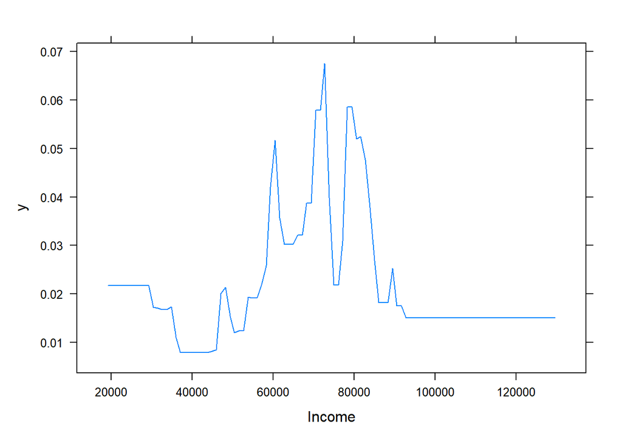

```r
plot(elect.boost, i='Income', type='response')
```

Remember, we set Donald Trump’s value to be 0. It appears that the greater the percentage of White people make up a county, the county is more favorable in voting for Donald Trump. As for income, counties appear to be more likely to vote for Joe Biden when average income is around 60k, 70k 80k. This is roughly middle, to upper-middle, class families. I want to note that the y-value observed in Income is extremely small, and I believe that has to do with the disproportional amount of favored-trumps that make up the Train data set.

```r
#Train Error Rate
rf.pred.tr <- predict(elect.rf, newdata = election.tr)
calc_error_rate(rf.pred.tr,election.tr$candidate)
```

```
## [1] 0
```

```r
#Test Error Rate
rf.pred.te <- predict(elect.rf, newdate=election.cl)
calc_error_rate(rf.pred.te,election.te$candidate)
```

```
## [1] 0.2860111
```

**20.** ## **REGRESSION** With supervised classification done, we now move on to another task. The goal will be: Can census information be used to predict the number of votes each candidate received per county?

```r
# we move all state and county names into lower-case
tmpvotes <- election.raw %>% ungroup %>%
  mutate_at(vars(state, county), tolower)

# we move all state and county names into lower-case
# we further remove suffixes of "county" and "parish"
tmpcensus <- census.clean %>% mutate_at(vars(State, County), tolower) %>%
  mutate(County = gsub(" county|  parish", "", County))

# we join the two datasets
election.reg <- tmpvotes %>%
  left_join(tmpcensus, by = c("state"="State", "county"="County")) %>%
  na.omit

# ## save meta information
# election.meta <- election.cl %>% select(c(county, party, CountyId, state, votes, pct, total))

#Remove all observations of candidates that are not Joe Biden or Donald Trump
election.reg <- election.reg %>% filter(candidate==c('Joe Biden', 'Donald Trump'))
#Create dummy variables for if the observation is Joe Biden or Donald Trump
election.reg$biden <- ifelse(election.reg$candidate=='Joe Biden', 1,0)
election.reg$trump <- ifelse(election.reg$candidate=='Donald Trump', 1,0)


## save predictors and class labels
election.reg = election.reg %>% select(-c(party))

#Remove all values where votes ==0
election.reg <- election.reg[election.reg$votes!=0,]
```

If we run our models as is, we are likely not going to get great results. As noted previously, Joe Biden and Donald Trump are the two candidates that obtained the vast majority of votes in the 2020 election. As such, our model should only focus on the vote totals of these candidates. Additionally, the candidates predictor is a nominal categorical variable. We need to mutate this variable into something numeric. So we use dummy variables to mutate the candidate variable into two variables that represent the characteristic. We NEED additional information for a regression model to work correctly. Not having a candidates variable will have each observation be identitcal in every value besides votes, which will likely lead to the same value being assigned twice per candidate for county observations.

**REGRESSION MODELLING** #Records Table (For later use)

```r
reg.records = matrix(NA, nrow=2, ncol=2)
colnames(reg.records) = c("train.MSE","test.MSE")
rownames(reg.records) = c("lasso","ridge")
```

```r
n <- nrow(election.reg)
idx.tr <- sample.int(n, 0.8*n)
election.tr <- election.reg[idx.tr,]
election.te <- election.reg[-idx.tr,]
```

LASSO MODELLING:

```r
#Perform Cross Validation for hyperparameter tuning
#DO NOT LEAVE CANDIDATE FOR x, this will result in the matrix containing data of type 'character', not 'numeric' as desired
x <- as.matrix( select(election.tr, -c(county, votes, CountyId,candidate, state)) )
y <- election.tr$votes

set.seed(10)

cv.out = cv.glmnet(x, y, alpha=1, lambda=seq(1,50)*1e-4)

bestlam = cv.out$lambda.min
```

```r
#Get train data
x.tr <- as.matrix(select(election.tr,-c(county, votes,CountyId,candidate, state)))
y.tr <- as.matrix(select(election.tr,votes))

#Lasso model, with best lambda
elect.lasso <- glmnet(x.tr, y.tr, alpha=1, lambda=bestlam)

#predict on train
lasso.pred.tr <- predict(elect.lasso, s= bestlam, newx=x.tr)


#Test Data w/ Predict on Test
x.te <- as.matrix(select(election.te, -c(county, votes,CountyId,candidate, state)))
y.te <- as.matrix(select(election.te, votes))
lasso.pred.te <- predict(elect.lasso,  s= bestlam, newx=x.te)
```

```r
#Get Lasso Coefficients
predict(elect.lasso,type='coefficients',s=bestlam)
```

```
## 27 x 1 sparse Matrix of class "dgCMatrix"
##                                1
## (Intercept)      -95451.93587711
## TotalPop              0.17767010
## Men                  11.98187112
## Women                 .
## White              -156.33918543
## VotingAgeCitizen    -80.84614599
## Income                0.05679153
## Poverty            -103.59270937
## ChildPoverty        123.77791938
## Professional        864.52808562
## Service             461.66249140
## Office              620.82141204
## Production           79.78265812
## Drive               108.98420539
## Carpool             153.36470651
## Transit           -1068.60708980
## OtherTransp         488.35874595
## WorkAtHome          500.52957115
## MeanCommute         214.68626644
## Employed            169.22565666
## PrivateWork         443.95739901
## SelfEmployed       -115.65462679
## FamilyWork          232.07017110
## Unemployment         53.69708258
## Minority           -118.56915314
## biden             -1783.52361689
## trump                 .
```

It appears that there is a negative relationship between ‘biden’, “Minority”, “Transit”, and “White” with vote totals. This is somewhat expected, as most counties favored Donald Trump, though “White” does pique my interest.

```r
mean(election.cl$candidate=='Donald Trump')
```

```
## [1] 0.7911357
```

80% of the observations favored Donald Trump. Most of these counties had lower populations

This has me interested for further analysis when I have the chance to revisit it.

```r
#Train MSE
paste("Train MSE: ", round(mean((lasso.pred.tr-y.tr)^2,4)) )
```

```
## [1] "Train MSE:  12899368"
```

```r
reg.records[1,1] = round(mean((lasso.pred.tr-y.tr)^2,4))
paste("Test MSE: ",  round(mean((lasso.pred.te-y.te)^2,4)) )
```

```
## [1] "Test MSE:  12792534"
```

```r
reg.records[1,2] = round(mean((lasso.pred.te-y.te)^2,4))
```

#RIDGE REGRESSION

```r
cor(x)
```

```
##                      TotalPop          Men        Women         White
## TotalPop          1.000000000 -0.115979096  0.115979096 -0.2240591689
## Men              -0.115979096  1.000000000 -1.000000000 -0.0268451269
## Women             0.115979096 -1.000000000  1.000000000  0.0268451269
## White            -0.224059169 -0.026845127  0.026845127  1.0000000000
## VotingAgeCitizen -0.241772905  0.068551466 -0.068551466  0.5438209146
## Income            0.291448790  0.037691392 -0.037691392  0.1353843871
## Poverty          -0.074452540 -0.073900599  0.073900599 -0.4955185372
## ChildPoverty     -0.058164556 -0.047855277  0.047855277 -0.4813493455
## Professional      0.278906866 -0.088198364  0.088198364  0.0745033201
## Service          -0.023277454  0.124493144 -0.124493144 -0.2570899716
## Office            0.193321940 -0.216822069  0.216822069 -0.0260819950
## Production       -0.192380290 -0.034207548  0.034207548  0.0922666901
## Drive            -0.071008272 -0.109151582  0.109151582  0.0003853247
## Carpool          -0.066497752  0.029219287 -0.029219287 -0.1676743701
## Transit           0.385762254 -0.067105740  0.067105740 -0.1848520562
## OtherTransp       0.053547874 -0.001210019  0.001210019 -0.0947458822
## WorkAtHome       -0.035420944  0.101324858 -0.101324858  0.1737206966
## MeanCommute       0.151946594 -0.067287312  0.067287312 -0.0081044423
## Employed         -0.030154710  0.111673099 -0.111673099  0.4590079978
## PrivateWork       0.218528725 -0.229288307  0.229288307  0.1551580035
## SelfEmployed     -0.177387237  0.125804086 -0.125804086  0.2307008020
## FamilyWork       -0.086548555  0.093607337 -0.093607337  0.0639942255
## Unemployment      0.030154710 -0.111673099  0.111673099 -0.4590079978
## Minority          0.219199301  0.030463478 -0.030463478 -0.9957009213
## biden            -0.008366089 -0.005481013  0.005481013  0.0015684470
## trump             0.008366089  0.005481013 -0.005481013 -0.0015684470
##                  VotingAgeCitizen       Income      Poverty ChildPoverty
## TotalPop            -0.2417729051  0.291448790 -0.074452540 -0.058164556
## Men                  0.0685514661  0.037691392 -0.073900599 -0.047855277
## Women               -0.0685514661 -0.037691392  0.073900599  0.047855277
## White                0.5438209146  0.135384387 -0.495518537 -0.481349345
## VotingAgeCitizen     1.0000000000 -0.222204423 -0.060929920 -0.042766088
## Income              -0.2222044235  1.000000000 -0.728720373 -0.697410264
## Poverty             -0.0609299203 -0.728720373  1.000000000  0.924607002
## ChildPoverty        -0.0427660879 -0.697410264  0.924607002  1.000000000
## Professional        -0.0037743629  0.562926077 -0.360800319 -0.435570688
## Service              0.1734375364 -0.314542914  0.345856299  0.332875270
## Office               0.0477773284  0.092119548 -0.026039723  0.001431710
## Production          -0.0235532182 -0.332748840  0.173146821  0.233457312
```

[output cut: 134 more lines]

```
## Production       -0.0027673917
## Drive            -0.0046551133
## Carpool          -0.0013368435
## Transit          -0.0092746643
## OtherTransp      -0.0090133042
## WorkAtHome        0.0145742133
## MeanCommute      -0.0034712645
## Employed          0.0048147752
## PrivateWork      -0.0246548856
## SelfEmployed      0.0144184829
## FamilyWork        0.0124844037
## Unemployment     -0.0048147752
## Minority          0.0003025951
## biden            -1.0000000000
## trump             1.0000000000
```

Obviously there are strong multicollinearities between several predictors (White and Minority, Men and Women, Poverty and ChildPoverty, Biden and Trump) . Perhaps a ridge regression model may eleviate this.

```r
#10-fold cv
lambda.list.ridge = 1000 * exp(seq(0,log(1e-5), length = 100))
ridge.cv = cv.glmnet(x.tr, y.tr, alpha=0, lambda=lambda.list.ridge)
#Get best lambda
bestlam = ridge.cv$lambda.min

#Ridge-Regression Model fitted to our training set

elect.ridge = glmnet(x.tr,y.tr, alpha=0,lambda=bestlam)

predict(elect.ridge,type='coefficients',s=bestlam)
```

```
## 27 x 1 sparse Matrix of class "dgCMatrix"
##                                1
## (Intercept)      -97967.99736819
## TotalPop              0.17304844
## Men                  -4.75101032
## Women                14.95491370
## White               -52.39043248
## VotingAgeCitizen    -88.29043354
## Income                0.07239075
## Poverty             -75.62767094
## ChildPoverty        106.91994876
## Professional        840.01961970
## Service             427.23806565
## Office              623.70148793
## Production           27.99055660
## Drive               115.62221979
## Carpool             136.85681294
## Transit            -914.35916724
## OtherTransp         484.81406789
## WorkAtHome          485.64085538
## MeanCommute         218.75429226
## Employed             90.26243657
## PrivateWork         460.77683941
## SelfEmployed       -117.36509140
## FamilyWork          255.41750392
## Unemployment        -14.88999806
## Minority             -4.82486014
## biden             -1237.47757399
## trump               576.53274257
```

```r
#Ridge - Train MSE
ridge.pred.tr = predict(elect.ridge, s=bestlam, newx=x.tr)
paste("Train MSE: ", round(mean((ridge.pred.tr-y.tr)^2),4) )
```

```
## [1] "Train MSE:  422298544.7387"
```

```r
reg.records[2,1] = round(mean((ridge.pred.tr-y.tr)^2),4)
#Ridge - Test MSE
ridge.pred.te = predict(elect.ridge, s=bestlam, newx=x.te)
paste("Test MSE: ", round(mean((ridge.pred.te-y.te  )^2),4) )
```

```
## [1] "Test MSE:  1348675697.1549"
```

```r
reg.records[2,2] = round(mean((ridge.pred.te-y.te)^2),4)
```

```r
reg.records
```

```
##       train.MSE   test.MSE
## lasso  12899368   12792534
## ridge 422298545 1348675697
```

It doesn’t seem like the ridge model faired better than our lasso approach. Let’s stick with the lasso model to see how well it did in it’s total predictions.

```r
#create a single vector of lasso predictions
lasso.pred <- c(lasso.pred.tr,lasso.pred.te)
typeof(lasso.pred)
```

```
## [1] "double"
```

```r
#remerge the train and test datasets, assign a column of predicted votes for our lasso predictions
election.reg <- rbind(election.tr,election.te)
election.reg['votes_pred'] <- lasso.pred
election.reg
```

```
## # A tibble: 3,222 x 32
##    state          county     candidate votes CountyId TotalPop   Men Women White
##    <chr>          <chr>      <fct>     <dbl>    <dbl>    <dbl> <dbl> <dbl> <dbl>
##  1 georgia        paulding   Joe Biden 29658    13223   152399  48.9  51.1  73
##  2 north carolina alleghany  Donald T~  4501    37005    10935  49.8  50.2  87.3
##  3 louisiana      pointe co~ Donald T~  7503    22077    22271  48.0  52.0  60.4
##  4 tennessee      stewart    Donald T~  4942    47161    13248  49.7  50.3  92
##  5 wisconsin      iowa       Joe Biden  7828    55049    23576  50.3  49.7  95.6
##  6 minnesota      blue earth Donald T~ 16721    27013    65767  50.3  49.7  88.9
##  7 arizona        yuma       Joe Biden 31562     4027   204281  51.4  48.6  31.8
##  8 illinois       bond       Donald T~  5612    17005    17034  51.5  48.5  87.8
##  9 virginia       halifax    Donald T~ 10404    51083    35030  47.1  52.9  59.8
## 10 iowa           humboldt   Joe Biden  1442    19091     9586  48.7  51.3  94
## # ... with 3,212 more rows, and 23 more variables: VotingAgeCitizen <dbl>,
## #   Income <dbl>, Poverty <dbl>, ChildPoverty <dbl>, Professional <dbl>,
## #   Service <dbl>, Office <dbl>, Production <dbl>, Drive <dbl>, Carpool <dbl>,
## #   Transit <dbl>, OtherTransp <dbl>, WorkAtHome <dbl>, MeanCommute <dbl>,
## #   Employed <dbl>, PrivateWork <dbl>, SelfEmployed <dbl>, FamilyWork <dbl>,
## #   Unemployment <dbl>, Minority <dbl>, biden <dbl>, trump <dbl>,
## #   votes_pred <dbl>
```

```r
#Similar to the initial analysis, create dataframes of predicted county and state values
election.reg.county <- election.reg
election.reg.state <- election.reg %>% group_by(state,candidate) %>% summarise(votes_pred=sum(votes_pred))
#county.winner (predicted)
pred.county.winner <- election.reg.county %>%
  group_by(county) %>%
  mutate(total=sum(votes_pred)) %>%
  mutate(pct=votes_pred/total) %>%
  top_n(n=1, wt=pct)
pred.county.winner
```

```
## # A tibble: 1,097 x 34
## # Groups:   county [1,097]
##    state        county      candidate  votes CountyId TotalPop   Men Women White
##    <chr>        <chr>       <fct>      <dbl>    <dbl>    <dbl> <dbl> <dbl> <dbl>
##  1 louisiana    pointe cou~ Donald Tr~  7503    22077    22271  48.0  52.0  60.4
##  2 tennessee    stewart     Donald Tr~  4942    47161    13248  49.7  50.3  92
##  3 minnesota    blue earth  Donald Tr~ 16721    27013    65767  50.3  49.7  88.9
##  4 illinois     bond        Donald Tr~  5612    17005    17034  51.5  48.5  87.8
##  5 virginia     halifax     Donald Tr~ 10404    51083    35030  47.1  52.9  59.8
##  6 colorado     gilpin      Donald Tr~  1815     8047     5793  53.7  46.3  86.2
##  7 missouri     st. franco~ Donald Tr~ 20506    29187    66248  54.0  46.0  92
##  8 arizona      yuma        Donald Tr~ 35766     4027   204281  51.4  48.6  31.8
##  9 virginia     waynesboro~ Donald Tr~  5507    51820    21620  48.3  51.7  77
## 10 south dakota ziebach     Donald Tr~   404    46137     2837  50.1  49.9  23.4
## # ... with 1,087 more rows, and 25 more variables: VotingAgeCitizen <dbl>,
## #   Income <dbl>, Poverty <dbl>, ChildPoverty <dbl>, Professional <dbl>,
## #   Service <dbl>, Office <dbl>, Production <dbl>, Drive <dbl>, Carpool <dbl>,
## #   Transit <dbl>, OtherTransp <dbl>, WorkAtHome <dbl>, MeanCommute <dbl>,
## #   Employed <dbl>, PrivateWork <dbl>, SelfEmployed <dbl>, FamilyWork <dbl>,
## #   Unemployment <dbl>, Minority <dbl>, biden <dbl>, trump <dbl>,
## #   votes_pred <dbl>, total <dbl>, pct <dbl>
```

```r
#state.winner (predicted)
pred.state.winner <- election.reg.state %>%
  group_by(state) %>%
  mutate(total=sum(votes_pred)) %>%
  mutate(pct=votes_pred/total) %>%
  top_n(n=1, wt=pct)
pred.state.winner
```

```
## # A tibble: 48 x 5
## # Groups:   state [48]
##    state                candidate    votes_pred    total   pct
##    <chr>                <fct>             <dbl>    <dbl> <dbl>
##  1 alabama              Donald Trump    884653. 1672996. 0.529
##  2 arizona              Donald Trump    210580.  408674. 0.515
##  3 arkansas             Donald Trump    412609.  757444. 0.545
##  4 california           Donald Trump   2009653. 3976501. 0.505
##  5 colorado             Donald Trump    754902. 1456299. 0.518
##  6 connecticut          Donald Trump    373474.  741597. 0.504
##  7 delaware             Donald Trump     40077.   78370. 0.511
##  8 district of columbia Donald Trump    108506.  215228. 0.504
##  9 florida              Donald Trump   1891620. 3722601. 0.508
## 10 georgia              Donald Trump   1330555. 2530913. 0.526
## # ... with 38 more rows
```

```r
#Predicted Results
states.join <- left_join(states, pred.state.winner)
```

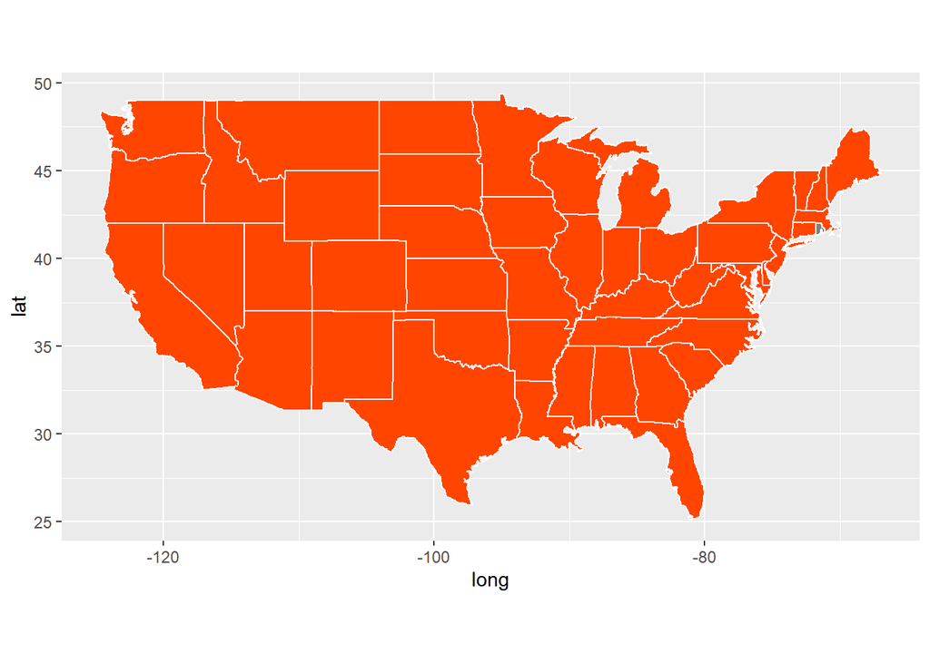

```r
ggplot(data=states.join)+
  geom_polygon(aes(x=long, y=lat, fill=candidate, group=group), color='white') +
  coord_fixed(1.3) +
  scale_fill_manual(values=c('orangered','steelblue')) + theme(legend.position='none')
```

```r
#added custom colors for aesthetic
```

Regression Analysis

```r
election.reg <- na.omit(election.reg)
x1 <- election.reg$TotalPop
x2 <- election.reg$Men
x3 <- election.reg$Women
x4 <- election.reg$White
x5 <- election.reg$Minority
x6 <- election.reg$Poverty
x7 <- election.reg$ChildPoverty
x8 <- election.reg$biden
x9 <- election.reg$trump
x10 <- election.reg$Employed
x11 <- election.reg$Unemployment
x12 <- election.reg$VotingAgeCitizen
x13 <- election.reg$Income
x14 <- election.reg$Professional
x15 <- election.reg$Service
x16 <- election.reg$Office
x17 <- election.reg$Production
x18 <- election.reg$Drive
x19 <- election.reg$Carpool
x20 <- election.reg$Transit
x21 <- election.reg$OtherTransp
x22 <- election.reg$WorkAtHome
x23 <- election.reg$MeanCommute
x24 <- election.reg$PrivateWork
x25 <- election.reg$SelfEmployed
x26 <- election.reg$FamilyWork
x27 <- election.reg$biden
x28 <- election.reg$trump
y <- election.reg$votes

#Obtain a model using stepwise regression

mod.0 = lm(y~1)
mod.U=lm(y~x1+x2+x3+x4+x5+x6+x7+x8+x9+x10+x11+x12+x13+x14+x15+x16+x17+x18+x19+x20+x21+x22+x23+x24+x25+x26+x27+x28)

s.lm <- step(mod.0, scope = list(lower=mod.0, upper=mod.U))
```

```
## Start:  AIC=70802.16
## y ~ 1
##
##        Df     Sum of Sq            RSS   AIC
## + x1    1 9340809144228  1913088937459 65095
## + x20   1 1274847031623  9979051050064 70417
## + x14   1 1038601618698 10215296462989 70492
## + x13   1  981301889123 10272596192564 70510
## + x24   1  618073985483 10635824096204 70622
## + x17   1  451516979341 10802381102346 70672
## + x16   1  445773969907 10808124111780 70674
## + x12   1  439472384564 10814425697123 70676
## + x4    1  398537882860 10855360198827 70688
## + x5    1  373083404497 10880814677190 70696
## + x25   1  365132388915 10888765692772 70698
## + x23   1  240423216745 11013474864942 70735
## + x2    1  158471287042 11095426794645 70758
## + x3    1  158471287042 11095426794645 70758
## + x6    1   97797287076 11156100794611 70776
## + x26   1   84100708955 11169797372733 70780
## + x19   1   74481624980 11179416456707 70783
## + x7    1   66153893278 11187744188409 70785
## + x18   1   43618124841 11210279956846 70792
## + x21   1   34625158624 11219272923064 70794
## + x15   1   16234458746 11237663622941 70800
## <none>                  11253898081687 70802
## + x10   1    2509209517 11251388872170 70803
## + x11   1    2509209517 11251388872170 70803
## + x22   1    1893049035 11252005032652 70804
## + x8    1     102842320 11253795239367 70804
## + x9    1     102842320 11253795239367 70804
## + x27   1     102842320 11253795239367 70804
## + x28   1     102842320 11253795239367 70804
##
## Step:  AIC=65094.79
## y ~ x1
##
##        Df     Sum of Sq            RSS   AIC
## + x20   1   33239184376  1879849753083 65040
## + x14   1   21112528532  1891976408927 65061
```

[output cut: 284 more lines]

```
## + x3    1     108612517 1809856704528 64934
## + x8    1     102842320 1809862474725 64934
## + x9    1     102842320 1809862474725 64934
## + x27   1     102842320 1809862474725 64934
## + x28   1     102842320 1809862474725 64934
## + x6    1      66929362 1809898387683 64934
## + x17   1       8550106 1809956766939 64934
## + x26   1        437332 1809964879713 64934
## + x13   1          1976 1809965315069 64934
## - x16   1    2669612072 1812634929117 64935
## - x22   1    3090598377 1813055915422 64936
## - x24   1   12045401235 1822010718280 64952
## - x14   1   34811824895 1844777141940 64992
## - x20   1   49297135477 1859262452522 65017
## - x1    1 6533091585800 8343056902845 69854
```

```r
summary(s.lm)
```

```
##
## Call:
## lm(formula = y ~ x1 + x20 + x14 + x24 + x16 + x15 + x23 + x22 +
##     x25)
##
## Residuals:
##     Min      1Q  Median      3Q     Max
## -564582   -4000    -361    3109  468574
##
## Coefficients:
##                  Estimate    Std. Error t value             Pr(>|t|)
## (Intercept) -60150.842721   9711.161626  -6.194   0.0000000006610775 ***
## x1               0.204004      0.001895 107.674 < 0.0000000000000002 ***
## x20          -1757.215754    187.871803  -9.353 < 0.0000000000000002 ***
## x14            674.626720     85.831658   7.860   0.0000000000000052 ***
## x24            362.422574     78.388429   4.623   0.0000039234733182 ***
## x16            321.156024    147.550047   2.177               0.0296 *
## x15            251.330509    134.291878   1.872               0.0614 .
## x23            159.206955     82.011998   1.941               0.0523 .
## x22            441.021415    188.315362   2.342               0.0192 *
## x25           -262.792249    167.251716  -1.571               0.1162
## ---
## Signif. codes:  0 '***' 0.001 '**' 0.01 '*' 0.05 '.' 0.1 ' ' 1
##
## Residual standard error: 23740 on 3212 degrees of freedom
## Multiple R-squared:  0.8392, Adjusted R-squared:  0.8387
## F-statistic:  1862 on 9 and 3212 DF,  p-value: < 0.00000000000000022
```

Stewpwise regression found x1,x20,x14,x24,x16,x15,x23,x22 to be the best predictors for vote totals. These predictors, respectively, are:

TotalPop - This should be expected, as there is a correlation between Totalpop and votes Transit - Similar to what we found in past models Professional PrivateWork Office Service MeanCommute WorkAtHome SelfEmployed

83% of the variance is explained with the model. We do have a wide range of residuals which may be an issue. Furthermore, biden and trump predictors were not found to be statistically signifigant, which may cause trouble down the line with predictions.

```r
library(leaps)
#Use best subsets regression and compare subsets with Mallow's Cp and adjusted R-squared, Compare with stepwise

mod = regsubsets(cbind(x1,x2,x3,x4,x5,x6,x7,x8,x9,x10,x11,x12,x13,x14,x15,x16,x17,x18,x19,x20,x21,x22,x23,x24,x25,x26), y, nvmax = 26)
```

```
## Reordering variables and trying again:
```

```r
summary.mod <- summary(mod)
summary.mod$which
```

```
##    (Intercept)   x1    x2    x3    x4    x5    x6    x7    x8    x9   x10   x11
## 1         TRUE TRUE FALSE FALSE FALSE FALSE FALSE FALSE FALSE FALSE FALSE FALSE
## 2         TRUE TRUE FALSE FALSE FALSE FALSE FALSE FALSE FALSE FALSE FALSE FALSE
## 3         TRUE TRUE FALSE FALSE FALSE FALSE FALSE FALSE FALSE FALSE FALSE FALSE
## 4         TRUE TRUE FALSE FALSE FALSE FALSE FALSE FALSE FALSE FALSE FALSE FALSE
## 5         TRUE TRUE FALSE FALSE FALSE FALSE FALSE FALSE FALSE FALSE FALSE FALSE
## 6         TRUE TRUE FALSE FALSE FALSE FALSE FALSE FALSE FALSE FALSE FALSE FALSE
## 7         TRUE TRUE FALSE FALSE FALSE FALSE FALSE FALSE FALSE FALSE FALSE FALSE
## 8         TRUE TRUE FALSE FALSE FALSE FALSE FALSE FALSE FALSE FALSE FALSE FALSE
## 9         TRUE TRUE FALSE FALSE FALSE FALSE FALSE FALSE FALSE FALSE FALSE FALSE
## 10        TRUE TRUE FALSE FALSE FALSE FALSE FALSE FALSE FALSE FALSE FALSE FALSE
## 11        TRUE TRUE FALSE FALSE  TRUE FALSE FALSE FALSE FALSE FALSE FALSE FALSE
## 12        TRUE TRUE FALSE FALSE  TRUE  TRUE FALSE FALSE FALSE FALSE FALSE FALSE
## 13        TRUE TRUE FALSE FALSE  TRUE  TRUE FALSE FALSE FALSE FALSE FALSE FALSE
## 14        TRUE TRUE FALSE FALSE  TRUE  TRUE FALSE FALSE FALSE FALSE FALSE FALSE
```

[output cut: 57 more lines]

```r
summary.mod$cp
```

```
##  [1] 165.37266433 108.58786578  55.22659378  10.45319519   6.48035508
##  [6]   3.31748959   0.62618837  -0.54516481  -1.00549463  -0.03733587
## [11]   0.91518348   1.69212494   2.73177144   4.21360913   5.94863665
## [16]   7.53668927   9.35480860  11.20595313  13.11345109  15.05447582
## [21]  17.01135222  19.00180279  21.00000000
```

```r
summary.mod$adjr2
```

```
##  [1] 0.8299538 0.8328563 0.8355886 0.8378904 0.8381406 0.8383501 0.8385361
##  [8] 0.8386455 0.8387193 0.8387211 0.8387236 0.8387350 0.8387332 0.8387091
## [15] 0.8386722 0.8386426 0.8386014 0.8385586 0.8385128 0.8384654 0.8384171
## [22] 0.8383670 0.8383166
```

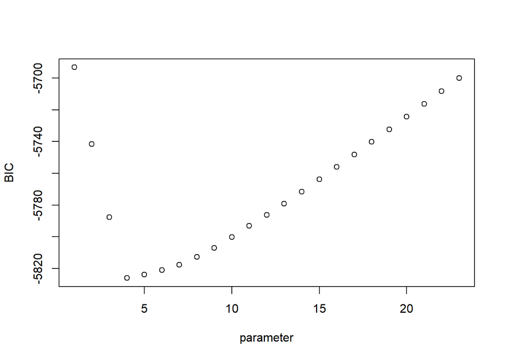

```r
plot(summary.mod$bic,xlab='parameter',ylab='BIC')
```

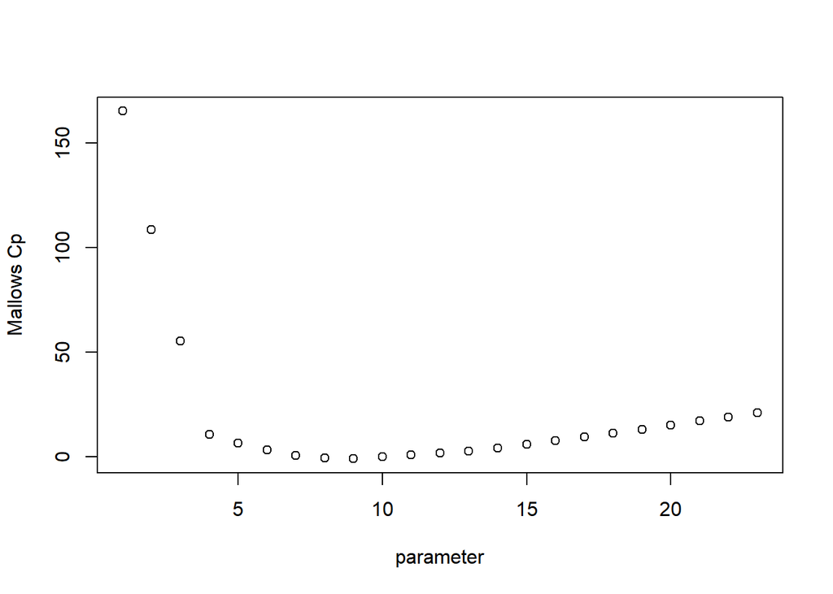

```r
plot(summary.mod$cp,xlab='parameter',ylab='Mallows Cp')
```

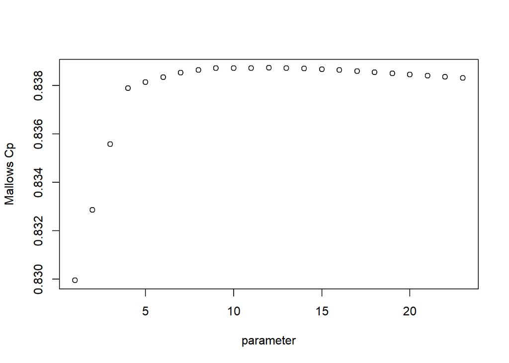

```r
plot(summary.mod$adjr2,xlab='parameter',ylab='Mallows Cp')
```

We want to favor a subset model with relatively low Cp/BIC valuess and relatively high aRSS. We can gather that the subset of 9 variables, the best of the 9-predictors models, is a good choice, these variables are also the same as found in the stepwise regression model, confirming results.

Now we have a rough idea on what the model should look like.

```r
reg.1 <- lm(y~x1+x20+x14+x24+x16+x15+x23+x22+x25)
```

Let’s now check on the correlations between these variables

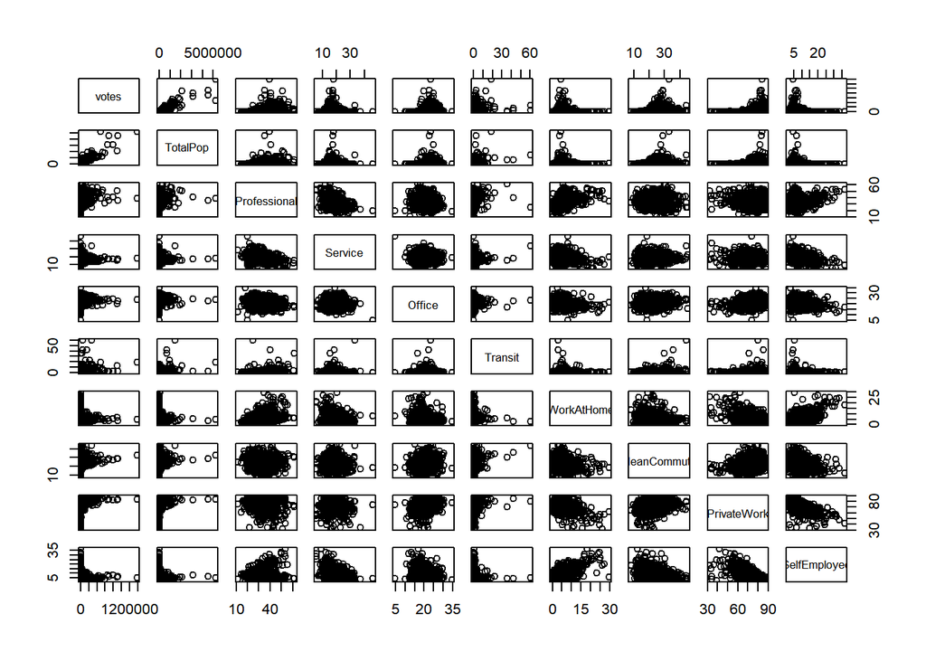

```r
#Better Identify variables
votes <- election.reg$votes
TotalPop <- x1
Transit <- x20
Professional <- x14
PrivateWork <- x24
Office <- x16
Service <- x15
MeanCommute <- x23
WorkAtHome <- x22
SelfEmployed <- x25

#Scatterplot matrix
pairs(~votes+TotalPop+Professional+Service+Office+Transit+WorkAtHome+MeanCommute+PrivateWork+SelfEmployed)
```

```r
#Correlation Matrix
subset.reg <- data.frame(votes,TotalPop,Professional,Service,Office,Transit,WorkAtHome,MeanCommute,PrivateWork,SelfEmployed)
cor(subset.reg)
```

```
##                    votes    TotalPop Professional     Service      Office
## votes         1.00000000  0.91104695   0.30378967 -0.03798109  0.19902419
## TotalPop      0.91104695  1.00000000   0.28792235 -0.02096481  0.18589480
## Professional  0.30378967  0.28792235   1.00000000 -0.29917714 -0.01131667
## Service      -0.03798109 -0.02096481  -0.29917714  1.00000000 -0.02743486
## Office        0.19902419  0.18589480  -0.01131667 -0.02743486  1.00000000
## Transit       0.33657166  0.42347416   0.26145928  0.06338982  0.03233523
## WorkAtHome   -0.01296969 -0.02839110   0.44157667 -0.17219383 -0.22960199
## MeanCommute   0.14616275  0.15463279  -0.12687272 -0.01882144  0.14971766
## PrivateWork   0.23435204  0.22330809  -0.20362269 -0.15358977  0.32519296
## SelfEmployed -0.18012487 -0.17817439   0.21984206 -0.21720830 -0.32435228
##                  Transit  WorkAtHome MeanCommute PrivateWork SelfEmployed
## votes         0.33657166 -0.01296969  0.14616275  0.23435204   -0.1801249
## TotalPop      0.42347416 -0.02839110  0.15463279  0.22330809   -0.1781744
## Professional  0.26145928  0.44157667 -0.12687272 -0.20362269    0.2198421
## Service       0.06338982 -0.17219383 -0.01882144 -0.15358977   -0.2172083
## Office        0.03233523 -0.22960199  0.14971766  0.32519296   -0.3243523
## Transit       1.00000000  0.01366012  0.18244386  0.08557021   -0.1207725
## WorkAtHome    0.01366012  1.00000000 -0.17749865 -0.45524693    0.6625030
## MeanCommute   0.18244386 -0.17749865  1.00000000  0.24136561   -0.2924840
## PrivateWork   0.08557021 -0.45524693  0.24136561  1.00000000   -0.6100695
## SelfEmployed -0.12077250  0.66250304 -0.29248403 -0.61006946    1.0000000
```

We can see Total Pop has a strong correlation with votes. Most other correlations are fairly weak. There’s a fair positive correlation between WorkAthome and SelfEmployed, and a fair negative correlation between SelfEmployed and PrivateWork. F-tests can be run to see if interaction terms between these two pairs would be beneficial to the model.

```r
#(Reference) Initial model
#reg.1 <- lm(y~x1+x20+x14+x24+x16+x15+x23+x22+x25)

#Model for interaction between WorkAtHome and SelfEmployed
reg.interact.1 <- lm(y~x1+x20+x14+x24+x16+x15+x23+x22+x25+I(x22*x25))

#General Linear F-test
anova(reg.1,reg.interact.1)
```

```
## Analysis of Variance Table
##
## Model 1: y ~ x1 + x20 + x14 + x24 + x16 + x15 + x23 + x22 + x25
## Model 2: y ~ x1 + x20 + x14 + x24 + x16 + x15 + x23 + x22 + x25 + I(x22 *
##     x25)
##   Res.Df           RSS Df  Sum of Sq      F Pr(>F)
## 1   3212 1809965317045
## 2   3211 1808668441686  1 1296875360 2.3024 0.1293
```

```r
#Model for interaction between WorkAtHome and SelfEmployed
reg.interact.2 <- lm(y~x1+x20+x14+x24+x16+x15+x23+x22+x25+I(x24*x25))

#General Linear F-test
anova(reg.1,reg.interact.2)
```

```
## Analysis of Variance Table
##
## Model 1: y ~ x1 + x20 + x14 + x24 + x16 + x15 + x23 + x22 + x25
## Model 2: y ~ x1 + x20 + x14 + x24 + x16 + x15 + x23 + x22 + x25 + I(x24 *
##     x25)
##   Res.Df           RSS Df Sum of Sq      F Pr(>F)
## 1   3212 1809965317045
## 2   3211 1809211960110  1 753356935 1.3371 0.2476
```

Finally we should see if high order terms should be included in the model

```r
#Testing Second Order terms

#(Reference) Initial model
#reg.1 <- lm(y~x1+x20+x14+x24+x16+x15+x23+x22+x25)

#TotalPop, second order
x1_2 <- x1**2
summary(lm(y~x1+x1_2))
```

```
##
## Call:
## lm(formula = y ~ x1 + x1_2)
##
## Residuals:
##     Min      1Q  Median      3Q     Max
## -455059   -2134      54    2121  443333
##
## Coefficients:
##                       Estimate         Std. Error t value            Pr(>|t|)
## (Intercept) -165.4401574930299  467.0206090512869  -0.354               0.723
## x1             0.2383687757653    0.0029157421909  81.752 <0.0000000000000002
## x1_2          -0.0000000112097    0.0000000008342 -13.438 <0.0000000000000002
##
## (Intercept)
## x1          ***
## x1_2        ***
## ---
## Signif. codes:  0 '***' 0.001 '**' 0.01 '*' 0.05 '.' 0.1 ' ' 1
##
## Residual standard error: 23720 on 3219 degrees of freedom
## Multiple R-squared:  0.839,  Adjusted R-squared:  0.8389
## F-statistic:  8390 on 2 and 3219 DF,  p-value: < 0.00000000000000022
```

```r
#Professional, second order
x14_2 <- x14**2
summary(lm(y~x14+x14_2))
```

```
##
## Call:
## lm(formula = y ~ x14 + x14_2)
##
## Residuals:
##     Min      1Q  Median      3Q     Max
## -163103  -15009   -5332    1719 1343196
##
## Coefficients:
##             Estimate Std. Error t value      Pr(>|t|)
## (Intercept) 26912.03   17101.48   1.574       0.11566
## x14         -2979.59    1008.87  -2.953       0.00317 **
## x14_2          84.37      14.55   5.799 0.00000000732 ***
## ---
## Signif. codes:  0 '***' 0.001 '**' 0.01 '*' 0.05 '.' 0.1 ' ' 1
##
## Residual standard error: 56040 on 3219 degrees of freedom
## Multiple R-squared:  0.1017, Adjusted R-squared:  0.1011
## F-statistic: 182.2 on 2 and 3219 DF,  p-value: < 0.00000000000000022
```

```r
#Service, second order
x15_2 <- x15**2
summary(lm(y~x15+x15_2))
```

```
##
## Call:
## lm(formula = y ~ x15 + x15_2)
##
## Residuals:
##     Min      1Q  Median      3Q     Max
##  -21595  -18500  -14601   -4976 1361829
##
## Coefficients:
##             Estimate Std. Error t value Pr(>|t|)
## (Intercept) -3721.50   13776.40  -0.270  0.78707
## x15          3074.38    1378.94   2.230  0.02585 *
## x15_2         -93.08      34.17  -2.724  0.00649 **
## ---
## Signif. codes:  0 '***' 0.001 '**' 0.01 '*' 0.05 '.' 0.1 ' ' 1
##
## Residual standard error: 59020 on 3219 degrees of freedom
## Multiple R-squared:  0.003738,   Adjusted R-squared:  0.003119
## F-statistic:  6.04 on 2 and 3219 DF,  p-value: 0.00241
```

```r
#Office, second order
x16_2 <- x16**2
summary(lm(y~x16+x16_2))
```

```
##
## Call:
## lm(formula = y ~ x16 + x16_2)
##
## Residuals:
##     Min      1Q  Median      3Q     Max
##  -89612  -17641   -9015    -688 1356195
##
## Coefficients:
##             Estimate Std. Error t value Pr(>|t|)
## (Intercept) -8962.36   29531.24  -0.303    0.762
## x16         -1407.44    2808.29  -0.501    0.616
## x16_2         124.42      66.39   1.874    0.061 .
## ---
## Signif. codes:  0 '***' 0.001 '**' 0.01 '*' 0.05 '.' 0.1 ' ' 1
##
## Residual standard error: 57910 on 3219 degrees of freedom
## Multiple R-squared:  0.04066,    Adjusted R-squared:  0.04006
## F-statistic: 68.21 on 2 and 3219 DF,  p-value: < 0.00000000000000022
```

```r
#Transit, second order
x20_2 <- x20**2
summary(lm(y~x20+x20_2))
```

```
##
## Call:
## lm(formula = y ~ x20 + x20_2)
##
## Residuals:
##     Min      1Q  Median      3Q     Max
## -286489  -11341   -6168    -486 1129693
##
## Coefficients:
##             Estimate Std. Error t value             Pr(>|t|)
## (Intercept)  6924.52    1048.80   6.602      0.0000000000472 ***
## x20         18921.09     708.92  26.690 < 0.0000000000000002 ***
## x20_2        -310.49      16.92 -18.353 < 0.0000000000000002 ***
## ---
## Signif. codes:  0 '***' 0.001 '**' 0.01 '*' 0.05 '.' 0.1 ' ' 1
##
## Residual standard error: 52980 on 3219 degrees of freedom
## Multiple R-squared:  0.1973, Adjusted R-squared:  0.1968
## F-statistic: 395.5 on 2 and 3219 DF,  p-value: < 0.00000000000000022
```

```r
#WorkAtHome, second order
x22_2 <- x22**2
summary(lm(y~x22+x22_2))
```

```
##
## Call:
## lm(formula = y ~ x22 + x22_2)
##
## Residuals:
##     Min      1Q  Median      3Q     Max
##  -24473  -18671  -13710   -4210 1361766
##
## Coefficients:
##             Estimate Std. Error t value   Pr(>|t|)
## (Intercept) 11098.89    2897.59   3.830    0.00013 ***
## x22          3155.31     801.22   3.938 0.00008385 ***
## x22_2        -185.06      40.14  -4.610 0.00000418 ***
## ---
## Signif. codes:  0 '***' 0.001 '**' 0.01 '*' 0.05 '.' 0.1 ' ' 1
##
## Residual standard error: 58930 on 3219 degrees of freedom
## Multiple R-squared:  0.006726,   Adjusted R-squared:  0.006109
## F-statistic:  10.9 on 2 and 3219 DF,  p-value: 0.00001918
```

```r
#MeanCommute, second order
x23_2 <- x23**2
summary(lm(y~x23+x23_2))
```

```
##
## Call:
## lm(formula = y ~ x23 + x23_2)
##
## Residuals:
##     Min      1Q  Median      3Q     Max
##  -33090  -20343  -11240    -619 1350691
##
## Coefficients:
##              Estimate Std. Error t value Pr(>|t|)
## (Intercept) -49983.78   13709.30  -3.646 0.000271 ***
## x23           4511.93    1145.78   3.938 0.000084 ***
## x23_2          -60.82      23.32  -2.609 0.009132 **
## ---
## Signif. codes:  0 '***' 0.001 '**' 0.01 '*' 0.05 '.' 0.1 ' ' 1
##
## Residual standard error: 58430 on 3219 degrees of freedom
## Multiple R-squared:  0.02343,    Adjusted R-squared:  0.02282
## F-statistic: 38.61 on 2 and 3219 DF,  p-value: < 0.00000000000000022
```

```r
#PrivateWork, second order
x24_2 <- x24**2
summary(lm(y~x24+x24_2))
```

```
##
## Call:
## lm(formula = y ~ x24 + x24_2)
##
## Residuals:
##     Min      1Q  Median      3Q     Max
##  -62991  -19183   -7917    4075 1335440
##
## Coefficients:
##              Estimate Std. Error t value             Pr(>|t|)
## (Intercept) 283923.13   43098.35   6.588  0.00000000005194792 ***
## x24          -9884.76    1236.94  -7.991  0.00000000000000184 ***
## x24_2           84.10       8.85   9.503 < 0.0000000000000002 ***
## ---
## Signif. codes:  0 '***' 0.001 '**' 0.01 '*' 0.05 '.' 0.1 ' ' 1
##
## Residual standard error: 56690 on 3219 degrees of freedom
## Multiple R-squared:  0.08071,    Adjusted R-squared:  0.08014
## F-statistic: 141.3 on 2 and 3219 DF,  p-value: < 0.00000000000000022
```

```r
#SelfEmployed, second order
x25_2 <- x25**2
summary(lm(y~x25+x25_2))
```

```
##
## Call:
## lm(formula = y ~ x25 + x25_2)
##
## Residuals:
##     Min      1Q  Median      3Q     Max
##  -49138  -18330   -9883    1219 1350757
##
## Coefficients:
##             Estimate Std. Error t value             Pr(>|t|)
## (Intercept) 59285.44    4004.91  14.803 < 0.0000000000000002 ***
## x25         -6560.23     755.12  -8.688 < 0.0000000000000002 ***
## x25_2         163.08      29.07   5.609          0.000000022 ***
## ---
## Signif. codes:  0 '***' 0.001 '**' 0.01 '*' 0.05 '.' 0.1 ' ' 1
##
## Residual standard error: 57880 on 3219 degrees of freedom
## Multiple R-squared:  0.04181,    Adjusted R-squared:  0.04122
## F-statistic: 70.23 on 2 and 3219 DF,  p-value: < 0.00000000000000022
```

All second order terms besides x16, Office, seem to need further testing. We put all signfigant second order terms into a new model and anova test to see if we should use the new model, labeled reg.2, or our initial model without second order terms, reg.1.

```r
reg.2 <- lm(y~x1+x20+x14+x24+x16+x15+x23+x22+x25+x1_2+x14_2+x15_2+x20_2+x22_2+x23_2+x24_2+x25_2)
anova(reg.1,reg.2)
```

```
## Analysis of Variance Table
##
## Model 1: y ~ x1 + x20 + x14 + x24 + x16 + x15 + x23 + x22 + x25
## Model 2: y ~ x1 + x20 + x14 + x24 + x16 + x15 + x23 + x22 + x25 + x1_2 +
##     x14_2 + x15_2 + x20_2 + x22_2 + x23_2 + x24_2 + x25_2
##   Res.Df           RSS Df    Sum of Sq      F                Pr(>F)
## 1   3212 1809965317045
## 2   3204 1708133511411  8 101831805634 23.876 < 0.00000000000000022 ***
## ---
## Signif. codes:  0 '***' 0.001 '**' 0.01 '*' 0.05 '.' 0.1 ' ' 1
```

The p-val generated from the test is less than 0.05, so the Null Hypothesis is rejected, we use our new model.

No we do further testing for signifigant third order terms.

```r
##Testing third Order terms

#(Reference) Initial model
#reg.1 <- lm(y~x1+x20+x14+x24+x16+x15+x23+x22+x25)

#TotalPop, third order
x1_3 <- x1**3
summary(lm(y~x1+x1_2+x1_3))
```

```
##
## Call:
## lm(formula = y ~ x1 + x1_2 + x1_3)
##
## Residuals:
##     Min      1Q  Median      3Q     Max
## -423701   -2356    -407    1926  473754
##
## Coefficients:
##                            Estimate              Std. Error t value
## (Intercept) 558.7463864493624896568 495.8754021692441256164   1.127
## x1            0.2210625176489360855   0.0049982927575243120  44.228
## x1_2          0.0000000085309684403   0.0000000047111482819   1.811
## x1_3         -0.0000000000000033609   0.0000000000000007895  -4.257
##                         Pr(>|t|)
## (Intercept)               0.2599
## x1          < 0.0000000000000002 ***
## x1_2                      0.0703 .
## x1_3                   0.0000213 ***
## ---
## Signif. codes:  0 '***' 0.001 '**' 0.01 '*' 0.05 '.' 0.1 ' ' 1
##
## Residual standard error: 23660 on 3218 degrees of freedom
## Multiple R-squared:  0.8399, Adjusted R-squared:  0.8398
## F-statistic:  5629 on 3 and 3218 DF,  p-value: < 0.00000000000000022
```

```r
#Professional, third order
x14_3 <- x14**3
summary(lm(y~x14+x14_2+x14_3))
```

```
##
## Call:
## lm(formula = y ~ x14 + x14_2 + x14_3)
##
## Residuals:
##     Min      1Q  Median      3Q     Max
## -115812  -14927   -4512    1963 1339857
##
## Coefficients:
##               Estimate Std. Error t value Pr(>|t|)
## (Intercept) 179626.231  50588.877   3.551 0.000390 ***
## x14         -16917.215   4461.274  -3.792 0.000152 ***
## x14_2          490.687    127.529   3.848 0.000122 ***
## x14_3           -3.776      1.177  -3.207 0.001355 **
## ---
## Signif. codes:  0 '***' 0.001 '**' 0.01 '*' 0.05 '.' 0.1 ' ' 1
##
## Residual standard error: 55960 on 3218 degrees of freedom
## Multiple R-squared:  0.1045, Adjusted R-squared:  0.1037
## F-statistic: 125.2 on 3 and 3218 DF,  p-value: < 0.00000000000000022
```

```r
#Service, third order
x15_3 <- x15**3
summary(lm(y~x15+x15_2+x15_3))
```

```
##
## Call:
## lm(formula = y ~ x15 + x15_2 + x15_3)
##
## Residuals:
##     Min      1Q  Median      3Q     Max
##  -36456  -19077  -14067   -3929 1360398
##
## Coefficients:
##               Estimate Std. Error t value  Pr(>|t|)
## (Intercept) -92094.376  28683.943  -3.211  0.001337 **
## x15          16481.324   4059.372   4.060 0.0000502 ***
## x15_2         -729.073    184.342  -3.955 0.0000782 ***
## x15_3            9.345      2.662   3.511  0.000453 ***
## ---
## Signif. codes:  0 '***' 0.001 '**' 0.01 '*' 0.05 '.' 0.1 ' ' 1
##
## Residual standard error: 58910 on 3218 degrees of freedom
## Multiple R-squared:  0.00754,    Adjusted R-squared:  0.006614
## F-statistic: 8.149 on 3 and 3218 DF,  p-value: 0.00002103
```

```r
#Transit, third order
x20_3 <- x20**3
summary(lm(y~x20+x20_2+x20_3))
```

```
##
## Call:
## lm(formula = y ~ x20 + x20_2 + x20_3)
##
## Residuals:
##     Min      1Q  Median      3Q     Max
## -201515  -11217   -3792    1145 1168606
##
## Coefficients:
##              Estimate Std. Error t value             Pr(>|t|)
## (Intercept)  4069.620   1101.746   3.694             0.000225 ***
## x20         25065.917   1055.418  23.750 < 0.0000000000000002 ***
## x20_2        -901.128     77.549 -11.620 < 0.0000000000000002 ***
## x20_3           8.708      1.116   7.801  0.00000000000000825 ***
## ---
## Signif. codes:  0 '***' 0.001 '**' 0.01 '*' 0.05 '.' 0.1 ' ' 1
##
## Residual standard error: 52490 on 3218 degrees of freedom
## Multiple R-squared:  0.2122, Adjusted R-squared:  0.2114
## F-statistic: 288.9 on 3 and 3218 DF,  p-value: < 0.00000000000000022
```

```r
#WorkAtHome, third order
x22_3 <- x22**3
summary(lm(y~x22+x22_2+x22_3))
```

```
##
## Call:
## lm(formula = y ~ x22 + x22_2 + x22_3)
##
## Residuals:
##     Min      1Q  Median      3Q     Max
##  -54112  -20395  -12862    -897 1358386
##
## Coefficients:
##              Estimate Std. Error t value         Pr(>|t|)
## (Intercept) -7167.896   4244.010  -1.689           0.0913 .
## x22         12196.509   1735.535   7.028 0.00000000000256 ***
## x22_2       -1266.439    188.667  -6.713 0.00000000002251 ***
## x22_3          31.372      5.349   5.865 0.00000000495910 ***
## ---
## Signif. codes:  0 '***' 0.001 '**' 0.01 '*' 0.05 '.' 0.1 ' ' 1
##
## Residual standard error: 58630 on 3218 degrees of freedom
## Multiple R-squared:  0.01723,    Adjusted R-squared:  0.01631
## F-statistic: 18.81 on 3 and 3218 DF,  p-value: 0.000000000004335
```

```r
#MeanCommute, third order
x23_3 <- x23**3
summary(lm(y~x23+x23_2+x23_3))
```

```
##
## Call:
## lm(formula = y ~ x23 + x23_2 + x23_3)
##
## Residuals:
##     Min      1Q  Median      3Q     Max
##  -33297  -20378  -10933    -579 1350017
##
## Coefficients:
##               Estimate Std. Error t value Pr(>|t|)
## (Intercept) -26306.936  36578.567  -0.719    0.472
## x23           1398.719   4603.870   0.304    0.761
## x23_2           68.082    186.093   0.366    0.715
## x23_3           -1.688      2.417  -0.698    0.485
##
## Residual standard error: 58440 on 3218 degrees of freedom
## Multiple R-squared:  0.02358,    Adjusted R-squared:  0.02267
## F-statistic:  25.9 on 3 and 3218 DF,  p-value: < 0.00000000000000022
```

```r
#PrivateWork, third order
x24_3 <- x24**3
summary(lm(y~x24+x24_2+x24_3))
```

```
##
## Call:
## lm(formula = y ~ x24 + x24_2 + x24_3)
##
## Residuals:
##     Min      1Q  Median      3Q     Max
##  -83627  -15966   -5796     212 1329147
##
## Coefficients:
##                 Estimate   Std. Error t value        Pr(>|t|)
## (Intercept) -667830.4000  149993.2304  -4.452 0.0000087800270 ***
## x24           37192.3220    7215.9193   5.154 0.0000002700765 ***
## x24_2          -662.8686     113.1644  -5.858 0.0000000051704 ***
## x24_3             3.8360       0.5794   6.621 0.0000000000417 ***
## ---
## Signif. codes:  0 '***' 0.001 '**' 0.01 '*' 0.05 '.' 0.1 ' ' 1
##
## Residual standard error: 56320 on 3218 degrees of freedom
## Multiple R-squared:  0.09307,    Adjusted R-squared:  0.09222
## F-statistic: 110.1 on 3 and 3218 DF,  p-value: < 0.00000000000000022
```

```r
#SelfEmployed, third order
x25_3 <- x25**3
summary(lm(y~x25+x25_2+x25_3))
```

```
##
## Call:
## lm(formula = y ~ x25 + x25_2 + x25_3)
##
## Residuals:
##     Min      1Q  Median      3Q     Max
##  -54512  -17810   -8978     722 1350069
##
## Coefficients:
##              Estimate Std. Error t value             Pr(>|t|)
## (Intercept) 68239.092   6985.009   9.769 < 0.0000000000000002 ***
## x25         -9265.387   1886.849  -4.911          0.000000954 ***
## x25_2         382.618    143.318   2.670              0.00763 **
## x25_3          -4.807      3.073  -1.564              0.11783
## ---
## Signif. codes:  0 '***' 0.001 '**' 0.01 '*' 0.05 '.' 0.1 ' ' 1
##
## Residual standard error: 57870 on 3218 degrees of freedom
## Multiple R-squared:  0.04254,    Adjusted R-squared:  0.04165
## F-statistic: 47.66 on 3 and 3218 DF,  p-value: < 0.00000000000000022
```

Third order interactions for MeanCommute and SelfEmployed don’t seem to be signfigant. Once we use an anova test to interpret model improvement.

```r
reg.3 <- lm(y~x1+x20+x14+x24+x16+x15+x23+x22+x25+
              x1_2+x14_2+x15_2+x20_2+x22_2+x23_2+x24_2+x25_2+
              x1_3+x14_3+x15_3+x20_3+x22_3+x24_3)
anova(reg.2,reg.3)
```

```
## Analysis of Variance Table
##
## Model 1: y ~ x1 + x20 + x14 + x24 + x16 + x15 + x23 + x22 + x25 + x1_2 +
##     x14_2 + x15_2 + x20_2 + x22_2 + x23_2 + x24_2 + x25_2
## Model 2: y ~ x1 + x20 + x14 + x24 + x16 + x15 + x23 + x22 + x25 + x1_2 +
##     x14_2 + x15_2 + x20_2 + x22_2 + x23_2 + x24_2 + x25_2 + x1_3 +
##     x14_3 + x15_3 + x20_3 + x22_3 + x24_3
##   Res.Df           RSS Df   Sum of Sq      F        Pr(>F)
## 1   3204 1708133511411
## 2   3198 1684280470397  6 23853041015 7.5484 0.00000004678 ***
## ---
## Signif. codes:  0 '***' 0.001 '**' 0.01 '*' 0.05 '.' 0.1 ' ' 1
```

```r
##Testing fourth Order terms

#(Reference) Initial model
#reg.1 <- lm(y~x1+x20+x14+x24+x16+x15+x23+x22+x25)

#TotalPop, fourth order
x1_4 <- x1**4
summary(lm(y~x1+x1_2+x1_3+x1_4))
```

```
##
## Call:
## lm(formula = y ~ x1 + x1_2 + x1_3 + x1_4)
##
## Residuals:
##     Min      1Q  Median      3Q     Max
## -424193   -2363    -409    1924  473262
##
## Coefficients:
##                                   Estimate                     Std. Error
## (Intercept) 573.61859608500560625543585047 530.06915980736346227786270902
## x1            0.22062832749618668803925914   0.00740449150247793948936836
## x1_2          0.00000000934889882897697797   0.00000001131729156632175661
## x1_3         -0.00000000000000372327017118   0.00000000000000462694960357
## x1_4          0.00000000000000000000004303   0.00000000000000000000054130
##             t value            Pr(>|t|)
## (Intercept)   1.082               0.279
## x1           29.797 <0.0000000000000002 ***
## x1_2          0.826               0.409
## x1_3         -0.805               0.421
## x1_4          0.079               0.937
## ---
## Signif. codes:  0 '***' 0.001 '**' 0.01 '*' 0.05 '.' 0.1 ' ' 1
##
## Residual standard error: 23660 on 3217 degrees of freedom
## Multiple R-squared:  0.8399, Adjusted R-squared:  0.8397
## F-statistic:  4220 on 4 and 3217 DF,  p-value: < 0.00000000000000022
```

```r
#Professional, fourth order
x14_4 <- x14**4
summary(lm(y~x14+x14_2+x14_3+x14_4))
```

```
##
## Call:
## lm(formula = y ~ x14 + x14_2 + x14_3 + x14_4)
##
## Residuals:
##     Min      1Q  Median      3Q     Max
## -105232  -13033   -5447     973 1340487
##
## Coefficients:
##                 Estimate   Std. Error t value Pr(>|t|)
## (Intercept) -245822.4753  123895.5318  -1.984 0.047328 *
## x14           36347.5275   14848.2902   2.448 0.014421 *
## x14_2         -1904.6486     649.5986  -2.932 0.003391 **
## x14_3            42.1145      12.2604   3.435 0.000600 ***
## x14_4            -0.3162       0.0841  -3.760 0.000173 ***
## ---
## Signif. codes:  0 '***' 0.001 '**' 0.01 '*' 0.05 '.' 0.1 ' ' 1
##
## Residual standard error: 55850 on 3217 degrees of freedom
## Multiple R-squared:  0.1085, Adjusted R-squared:  0.1073
## F-statistic: 97.83 on 4 and 3217 DF,  p-value: < 0.00000000000000022
```

```r
#Service, fourth order
x15_4 <- x15**4
summary(lm(y~x15+x15_2+x15_3+x15_4))
```

```
##
## Call:
## lm(formula = y ~ x15 + x15_2 + x15_3 + x15_4)
##
## Residuals:
##     Min      1Q  Median      3Q     Max
##  -23710  -19259  -13696   -3630 1360537
##
## Coefficients:
##                 Estimate   Std. Error t value Pr(>|t|)
## (Intercept) -152596.3546   56981.7578  -2.678  0.00744 **
## x15           29179.5561   11102.5177   2.628  0.00862 **
## x15_2         -1655.2425     775.9361  -2.133  0.03298 *
## x15_3            37.1111      22.7521   1.631  0.10297
## x15_4            -0.2866       0.2333  -1.229  0.21924
## ---
## Signif. codes:  0 '***' 0.001 '**' 0.01 '*' 0.05 '.' 0.1 ' ' 1
##
## Residual standard error: 58910 on 3217 degrees of freedom
## Multiple R-squared:  0.008005,   Adjusted R-squared:  0.006772
## F-statistic:  6.49 on 4 and 3217 DF,  p-value: 0.0000337
```

```r
#Transit, fourth order
x20_4 <- x20**4
summary(lm(y~x20+x20_2+x20_3+x20_4))
```

```
##
## Call:
## lm(formula = y ~ x20 + x20_2 + x20_3 + x20_4)
##
## Residuals:
##     Min      1Q  Median      3Q     Max
## -220368  -11023   -4775     523 1142527
##
## Coefficients:
##                Estimate  Std. Error t value             Pr(>|t|)
## (Intercept)  5206.88757  1189.80192   4.376            0.0000125 ***
## x20         22006.25744  1608.46403  13.682 < 0.0000000000000002 ***
## x20_2        -354.12917   230.54311  -1.536               0.1246
## x20_3         -11.86611     8.24254  -1.440               0.1501
## x20_4           0.20591     0.08174   2.519               0.0118 *
## ---
## Signif. codes:  0 '***' 0.001 '**' 0.01 '*' 0.05 '.' 0.1 ' ' 1
##
## Residual standard error: 52450 on 3217 degrees of freedom
## Multiple R-squared:  0.2137, Adjusted R-squared:  0.2127
## F-statistic: 218.6 on 4 and 3217 DF,  p-value: < 0.00000000000000022
```

```r
#WorkAtHome, fourth order
x22_4 <- x22**4
summary(lm(y~x22+x22_2+x22_3+x22_4))
```

```
##
## Call:
## lm(formula = y ~ x22 + x22_2 + x22_3 + x22_4)
##
## Residuals:
##     Min      1Q  Median      3Q     Max
##  -27442  -20791  -12459     162 1356729
##
## Coefficients:
##                Estimate  Std. Error t value       Pr(>|t|)
## (Intercept) -19706.7961   5916.0278  -3.331       0.000875 ***
## x22          20697.5564   3291.4922   6.288 0.000000000365 ***
## x22_2        -2888.1179    566.0587  -5.102 0.000000355279 ***
## x22_3          137.2782     35.2663   3.893       0.000101 ***
## x22_4           -2.1229      0.6988  -3.038       0.002400 **
## ---
## Signif. codes:  0 '***' 0.001 '**' 0.01 '*' 0.05 '.' 0.1 ' ' 1
##
## Residual standard error: 58550 on 3217 degrees of freedom
## Multiple R-squared:  0.02004,    Adjusted R-squared:  0.01882
## F-statistic: 16.45 on 4 and 3217 DF,  p-value: 0.0000000000002396
```

```r
#PrivateWork, fourth order
x24_4 <- x24**4
summary(lm(y~x24+x24_2+x24_3+x24_4))
```

```
##
## Call:
## lm(formula = y ~ x24 + x24_2 + x24_3 + x24_4)
##
## Residuals:
##     Min      1Q  Median      3Q     Max
##  -97071  -14159   -5616    -938 1327687
##
## Coefficients:
##                  Estimate    Std. Error t value Pr(>|t|)
## (Intercept) 1358899.00156  604164.34235   2.249 0.024566 *
## x24         -102699.78819   41037.70317  -2.503 0.012379 *
## x24_2          2820.87438    1012.41934   2.786 0.005363 **
## x24_3           -33.55672      10.81441  -3.103 0.001933 **
## x24_4             0.14676       0.04238   3.463 0.000542 ***
## ---
## Signif. codes:  0 '***' 0.001 '**' 0.01 '*' 0.05 '.' 0.1 ' ' 1
##
## Residual standard error: 56220 on 3217 degrees of freedom
## Multiple R-squared:  0.09643,    Adjusted R-squared:  0.09531
## F-statistic: 85.84 on 4 and 3217 DF,  p-value: < 0.00000000000000022
```

Fourth Order Terms for TotalPop and Service (x1 & x15) are not signifigant. We once again run an anova test.

```r
reg.4 <- lm(y~x1+x20+x14+x24+x16+x15+x23+x22+x25+
              x1_2+x14_2+x15_2+x20_2+x22_2+x23_2+x24_2+x25_2+
              x1_3+x14_3+x15_3+x20_3+x22_3+x24_3+
              x14_4+x20_4+x22_4+x24_4)
anova(reg.3,reg.4)
```

```
## Analysis of Variance Table
##
## Model 1: y ~ x1 + x20 + x14 + x24 + x16 + x15 + x23 + x22 + x25 + x1_2 +
##     x14_2 + x15_2 + x20_2 + x22_2 + x23_2 + x24_2 + x25_2 + x1_3 +
##     x14_3 + x15_3 + x20_3 + x22_3 + x24_3
## Model 2: y ~ x1 + x20 + x14 + x24 + x16 + x15 + x23 + x22 + x25 + x1_2 +
##     x14_2 + x15_2 + x20_2 + x22_2 + x23_2 + x24_2 + x25_2 + x1_3 +
##     x14_3 + x15_3 + x20_3 + x22_3 + x24_3 + x14_4 + x20_4 + x22_4 +
##     x24_4
##   Res.Df           RSS Df  Sum of Sq      F Pr(>F)
## 1   3198 1684280470397
## 2   3194 1675121184397  4 9159286000 4.3661 0.0016 **
## ---
## Signif. codes:  0 '***' 0.001 '**' 0.01 '*' 0.05 '.' 0.1 ' ' 1
```

```r
##Testing fifth Order terms

#(Reference) Initial model
#reg.1 <- lm(y~x1+x20+x14+x24+x16+x15+x23+x22+x25)



#Professional, fifth order
x14_5 <- x14**5
summary(lm(y~x14+x14_2+x14_3+x14_4+x14_5))
```

```
##
## Call:
## lm(formula = y ~ x14 + x14_2 + x14_3 + x14_4 + x14_5)
##
## Residuals:
##     Min      1Q  Median      3Q     Max
## -108255  -13164   -5357    1090 1341306
##
## Coefficients:
##                  Estimate    Std. Error t value Pr(>|t|)
## (Intercept) -53716.598489 275830.300554  -0.195    0.846
## x14           4856.413407  43039.815017   0.113    0.910
## x14_2           61.860622   2604.962923   0.024    0.981
## x14_3          -16.567068     76.269277  -0.217    0.828
## x14_4            0.522875      1.079709   0.484    0.628
## x14_5           -0.004612      0.005916  -0.780    0.436
##
## Residual standard error: 55850 on 3216 degrees of freedom
## Multiple R-squared:  0.1086, Adjusted R-squared:  0.1072
## F-statistic: 78.38 on 5 and 3216 DF,  p-value: < 0.00000000000000022
```

```r
#Transit, fifth order
x20_5 <- x20**5
summary(lm(y~x20+x20_2+x20_3+x20_4+x20_5))
```

```
##
## Call:
## lm(formula = y ~ x20 + x20_2 + x20_3 + x20_4 + x20_5)
##
## Residuals:
##     Min      1Q  Median      3Q     Max
## -212716  -11599   -3432    1366 1123103
##
## Coefficients:
##                 Estimate   Std. Error t value             Pr(>|t|)
## (Intercept)  3578.216786  1262.127148   2.835             0.004610 **
## x20         27580.790685  2173.264652  12.691 < 0.0000000000000002 ***
## x20_2       -2119.707283   517.949461  -4.092            0.0000437 ***
## x20_3         128.738597    37.859763   3.400             0.000681 ***
## x20_4          -3.539150     0.987697  -3.583             0.000344 ***
## x20_5           0.031092     0.008172   3.805             0.000145 ***
## ---
## Signif. codes:  0 '***' 0.001 '**' 0.01 '*' 0.05 '.' 0.1 ' ' 1
##
## Residual standard error: 52340 on 3216 degrees of freedom
## Multiple R-squared:  0.2172, Adjusted R-squared:  0.216
## F-statistic: 178.5 on 5 and 3216 DF,  p-value: < 0.00000000000000022
```

```r
#WorkAtHome, fifth order
x22_5 <- x22**5
summary(lm(y~x22+x22_2+x22_3+x22_4+x22_5))
```

```
##
## Call:
## lm(formula = y ~ x22 + x22_2 + x22_3 + x22_4 + x22_5)
##
## Residuals:
##     Min      1Q  Median      3Q     Max
##  -27441  -20787  -12461     152 1356728
##
## Coefficients:
##                   Estimate     Std. Error t value Pr(>|t|)
## (Intercept) -19735.6311381   7865.9210197  -2.509 0.012156 *
## x22          20722.9985530   5634.7325709   3.678 0.000239 ***
## x22_2        -2894.9507160   1352.3579876  -2.141 0.032376 *
## x22_3          138.0038462    135.1201207   1.021 0.307169
## x22_4           -2.1548231      5.7768837  -0.373 0.709167
## x22_5            0.0004856      0.0872768   0.006 0.995561
## ---
## Signif. codes:  0 '***' 0.001 '**' 0.01 '*' 0.05 '.' 0.1 ' ' 1
##
## Residual standard error: 58560 on 3216 degrees of freedom
## Multiple R-squared:  0.02004,    Adjusted R-squared:  0.01852
## F-statistic: 13.15 on 5 and 3216 DF,  p-value: 0.00000000000105
```

```r
#PrivateWork, fifth order
x24_5 <- x24**5
summary(lm(y~x24+x24_2+x24_3+x24_4+x24_5))
```

```
##
## Call:
## lm(formula = y ~ x24 + x24_2 + x24_3 + x24_4 + x24_5)
##
## Residuals:
##     Min      1Q  Median      3Q     Max
## -101508  -13885   -5799    -895 1327864
##
## Coefficients:
##                   Estimate     Std. Error t value Pr(>|t|)
## (Intercept) -835749.131331 2442772.478209  -0.342    0.732
## x24           90168.916521  212014.161315   0.425    0.671
## x24_2         -3754.058035    7162.825500  -0.524    0.600
## x24_3            75.577143     118.194142   0.639    0.523
## x24_4            -0.738236       0.955390  -0.773    0.440
## x24_5             0.002813       0.003034   0.927    0.354
##
## Residual standard error: 56220 on 3216 degrees of freedom
## Multiple R-squared:  0.09668,    Adjusted R-squared:  0.09527
## F-statistic: 68.84 on 5 and 3216 DF,  p-value: < 0.00000000000000022
```

Fifth order terms for Professional, WorkAtHome, and PrivateWork are not signifigant.

```r
reg.5 <- lm(y~x1+x20+x14+x24+x16+x15+x23+x22+x25+
              x1_2+x14_2+x15_2+x20_2+x22_2+x23_2+x24_2+x25_2+
              x1_3+x14_3+x15_3+x20_3+x22_3+x24_3+
              x14_4+x20_4+x22_4+x24_4+
              x20_5)
anova(reg.4,reg.5)
```

```
## Analysis of Variance Table
##
## Model 1: y ~ x1 + x20 + x14 + x24 + x16 + x15 + x23 + x22 + x25 + x1_2 +
##     x14_2 + x15_2 + x20_2 + x22_2 + x23_2 + x24_2 + x25_2 + x1_3 +
##     x14_3 + x15_3 + x20_3 + x22_3 + x24_3 + x14_4 + x20_4 + x22_4 +
##     x24_4
## Model 2: y ~ x1 + x20 + x14 + x24 + x16 + x15 + x23 + x22 + x25 + x1_2 +
##     x14_2 + x15_2 + x20_2 + x22_2 + x23_2 + x24_2 + x25_2 + x1_3 +
##     x14_3 + x15_3 + x20_3 + x22_3 + x24_3 + x14_4 + x20_4 + x22_4 +
##     x24_4 + x20_5
##   Res.Df           RSS Df   Sum of Sq      F      Pr(>F)
## 1   3194 1675121184397
## 2   3193 1664402417249  1 10718767147 20.563 0.000005982 ***
## ---
## Signif. codes:  0 '***' 0.001 '**' 0.01 '*' 0.05 '.' 0.1 ' ' 1
```

Adding x20_5 to the model is a statistically signfigiant improvement, we continue adding higher order terms for x_20

```r
##Testing sixth Order terms

#(Reference) Initial model
#reg.1 <- lm(y~x1+x20+x14+x24+x16+x15+x23+x22+x25)

#Transit, sixth order
x20_6 <- x20**6
summary(lm(y~x20+x20_2+x20_3+x20_4+x20_5+x20_6))
```

```
##
## Call:
## lm(formula = y ~ x20 + x20_2 + x20_3 + x20_4 + x20_5 + x20_6)
##
## Residuals:
##     Min      1Q  Median      3Q     Max
## -250532  -14027   -2277    3299 1042277
##
## Coefficients:
##                  Estimate    Std. Error t value             Pr(>|t|)
## (Intercept)    92.3305440  1321.8279327   0.070                0.944
## x20         41936.5710303  2788.8354412  15.037 < 0.0000000000000002 ***
## x20_2       -8619.9561009   953.0399531  -9.045 < 0.0000000000000002 ***
## x20_3         931.9263331   106.1001515   8.783 < 0.0000000000000002 ***
## x20_4         -41.8376139     4.8328820  -8.657 < 0.0000000000000002 ***
## x20_5           0.7948599     0.0947323   8.391 < 0.0000000000000002 ***
## x20_6          -0.0053241     0.0006579  -8.092 0.000000000000000824 ***
## ---
## Signif. codes:  0 '***' 0.001 '**' 0.01 '*' 0.05 '.' 0.1 ' ' 1
##
## Residual standard error: 51820 on 3215 degrees of freedom
## Multiple R-squared:  0.2329, Adjusted R-squared:  0.2314
## F-statistic: 162.7 on 6 and 3215 DF,  p-value: < 0.00000000000000022
```

```r
reg.6 <- lm(y~x1+x20+x14+x24+x16+x15+x23+x22+x25+
              x1_2+x14_2+x15_2+x20_2+x22_2+x23_2+x24_2+x25_2+
              x1_3+x14_3+x15_3+x20_3+x22_3+x24_3+
              x14_4+x20_4+x22_4+x24_4+
              x20_5+
              x20_6)
anova(reg.5,reg.6)
```

```
## Analysis of Variance Table
##
## Model 1: y ~ x1 + x20 + x14 + x24 + x16 + x15 + x23 + x22 + x25 + x1_2 +
##     x14_2 + x15_2 + x20_2 + x22_2 + x23_2 + x24_2 + x25_2 + x1_3 +
##     x14_3 + x15_3 + x20_3 + x22_3 + x24_3 + x14_4 + x20_4 + x22_4 +
##     x24_4 + x20_5
## Model 2: y ~ x1 + x20 + x14 + x24 + x16 + x15 + x23 + x22 + x25 + x1_2 +
##     x14_2 + x15_2 + x20_2 + x22_2 + x23_2 + x24_2 + x25_2 + x1_3 +
##     x14_3 + x15_3 + x20_3 + x22_3 + x24_3 + x14_4 + x20_4 + x22_4 +
##     x24_4 + x20_5 + x20_6
##   Res.Df           RSS Df  Sum of Sq      F    Pr(>F)
## 1   3193 1664402417249
## 2   3192 1656843256196  1 7559161054 14.563 0.0001381 ***
## ---
## Signif. codes:  0 '***' 0.001 '**' 0.01 '*' 0.05 '.' 0.1 ' ' 1
```

```r
##Testing seventh Order terms

#(Reference) Initial model
#reg.1 <- lm(y~x1+x20+x14+x24+x16+x15+x23+x22+x25)

#Transit, sixth order
x20_7 <- x20**7
summary(lm(y~x20+x20_2+x20_3+x20_4+x20_5+x20_6+x20_7))
```

```
##
## Call:
## lm(formula = y ~ x20 + x20_2 + x20_3 + x20_4 + x20_5 + x20_6 +
##     x20_7)
##
## Residuals:
##     Min      1Q  Median      3Q     Max
## -346013  -12008   -2582    2003 1020370
##
## Coefficients:
##                   Estimate     Std. Error t value            Pr(>|t|)
## (Intercept)  2484.07117185  1398.50137635   1.776             0.07579 .
## x20         29674.70756437  3681.23104323   8.061 0.00000000000000106 ***
## x20_2        -685.09801823  1828.69017905  -0.375             0.70795
## x20_3        -543.48484277   309.23627976  -1.758             0.07893 .
## x20_4          70.39609678    22.62492950   3.111             0.00188 **
## x20_5          -3.16381271     0.78543297  -4.028 0.00005752741502215 ***
## x20_6           0.05919446     0.01272516   4.652 0.00000342385015671 ***
## x20_7          -0.00039128     0.00007707  -5.077 0.00000040548480266 ***
## ---
## Signif. codes:  0 '***' 0.001 '**' 0.01 '*' 0.05 '.' 0.1 ' ' 1
##
## Residual standard error: 51620 on 3214 degrees of freedom
## Multiple R-squared:  0.239,  Adjusted R-squared:  0.2373
## F-statistic: 144.2 on 7 and 3214 DF,  p-value: < 0.00000000000000022
```

```r
reg.7 <- lm(y~x1+x20+x14+x24+x16+x15+x23+x22+x25+
              x1_2+x14_2+x15_2+x20_2+x22_2+x23_2+x24_2+x25_2+
              x1_3+x14_3+x15_3+x20_3+x22_3+x24_3+
              x14_4+x20_4+x22_4+x24_4+
              x20_5+
              x20_6+
              x20_7)
anova(reg.6,reg.7)
```

```
## Analysis of Variance Table
##
## Model 1: y ~ x1 + x20 + x14 + x24 + x16 + x15 + x23 + x22 + x25 + x1_2 +
##     x14_2 + x15_2 + x20_2 + x22_2 + x23_2 + x24_2 + x25_2 + x1_3 +
##     x14_3 + x15_3 + x20_3 + x22_3 + x24_3 + x14_4 + x20_4 + x22_4 +
##     x24_4 + x20_5 + x20_6
## Model 2: y ~ x1 + x20 + x14 + x24 + x16 + x15 + x23 + x22 + x25 + x1_2 +
##     x14_2 + x15_2 + x20_2 + x22_2 + x23_2 + x24_2 + x25_2 + x1_3 +
##     x14_3 + x15_3 + x20_3 + x22_3 + x24_3 + x14_4 + x20_4 + x22_4 +
##     x24_4 + x20_5 + x20_6 + x20_7
##   Res.Df           RSS Df  Sum of Sq      F  Pr(>F)
## 1   3192 1656843256196
## 2   3191 1654594763532  1 2248492663 4.3364 0.03739 *
## ---
## Signif. codes:  0 '***' 0.001 '**' 0.01 '*' 0.05 '.' 0.1 ' ' 1
```

```r
##Testing eigth Order terms

#(Reference) Initial model
#reg.1 <- lm(y~x1+x20+x14+x24+x16+x15+x23+x22+x25)

#Transit, eigth order
x20_8 <- x20**8
summary(lm(y~x20+x20_2+x20_3+x20_4+x20_5+x20_6+x20_7+x20_8))
```

```
##
## Call:
## lm(formula = y ~ x20 + x20_2 + x20_3 + x20_4 + x20_5 + x20_6 +
##     x20_7 + x20_8)
##
## Residuals:
##     Min      1Q  Median      3Q     Max
## -276860   -8371   -5152     902  925273
##
## Coefficients:
##                   Estimate     Std. Error t value             Pr(>|t|)
## (Intercept)  7118.22765034  1469.43701437   4.844   0.0000013314501617 ***
## x20           -73.39928929  4861.98709270  -0.015                0.988
## x20_2       25824.04927016  3397.50718943   7.601   0.0000000000000384 ***
## x20_3       -7692.15937654   834.03433165  -9.223 < 0.0000000000000002 ***
## x20_4         896.39389302    92.42085327   9.699 < 0.0000000000000002 ***
## x20_5         -50.29153826     5.17522967  -9.718 < 0.0000000000000002 ***
## x20_6           1.44322956     0.15079347   9.571 < 0.0000000000000002 ***
## x20_7          -0.02034657     0.00216795  -9.385 < 0.0000000000000002 ***
## x20_8           0.00011120     0.00001207   9.210 < 0.0000000000000002 ***
## ---
## Signif. codes:  0 '***' 0.001 '**' 0.01 '*' 0.05 '.' 0.1 ' ' 1
##
## Residual standard error: 50960 on 3213 degrees of freedom
## Multiple R-squared:  0.2585, Adjusted R-squared:  0.2567
## F-statistic:   140 on 8 and 3213 DF,  p-value: < 0.00000000000000022
```

```r
reg.8 <- lm(y~x1+x20+x14+x24+x16+x15+x23+x22+x25+
              x1_2+x14_2+x15_2+x20_2+x22_2+x23_2+x24_2+x25_2+
              x1_3+x14_3+x15_3+x20_3+x22_3+x24_3+
              x14_4+x20_4+x22_4+x24_4+
              x20_5+
              x20_6+
              x20_7+
              x20_8)
anova(reg.7,reg.8)
```

```
## Analysis of Variance Table
##
## Model 1: y ~ x1 + x20 + x14 + x24 + x16 + x15 + x23 + x22 + x25 + x1_2 +
##     x14_2 + x15_2 + x20_2 + x22_2 + x23_2 + x24_2 + x25_2 + x1_3 +
##     x14_3 + x15_3 + x20_3 + x22_3 + x24_3 + x14_4 + x20_4 + x22_4 +
##     x24_4 + x20_5 + x20_6 + x20_7
## Model 2: y ~ x1 + x20 + x14 + x24 + x16 + x15 + x23 + x22 + x25 + x1_2 +
##     x14_2 + x15_2 + x20_2 + x22_2 + x23_2 + x24_2 + x25_2 + x1_3 +
##     x14_3 + x15_3 + x20_3 + x22_3 + x24_3 + x14_4 + x20_4 + x22_4 +
##     x24_4 + x20_5 + x20_6 + x20_7 + x20_8
##   Res.Df           RSS Df  Sum of Sq      F  Pr(>F)
## 1   3191 1654594763532
## 2   3190 1652575221516  1 2019542017 3.8984 0.04842 *
## ---
## Signif. codes:  0 '***' 0.001 '**' 0.01 '*' 0.05 '.' 0.1 ' ' 1
```

```r
##Testing ninth Order terms

#(Reference) Initial model
#reg.1 <- lm(y~x1+x20+x14+x24+x16+x15+x23+x22+x25)

#Transit, ninth order
x20_9 <- x20**9
summary(lm(y~x20+x20_2+x20_3+x20_4+x20_5+x20_6+x20_7+x20_8+x20_9))
```

```
##
## Call:
## lm(formula = y ~ x20 + x20_2 + x20_3 + x20_4 + x20_5 + x20_6 +
##     x20_7 + x20_8 + x20_9)
##
## Residuals:
##     Min      1Q  Median      3Q     Max
## -263731  -11952   -3210    1606  842629
##
## Coefficients:
##                     Estimate       Std. Error t value             Pr(>|t|)
## (Intercept)   2591.964130120   1509.101828295   1.718             0.085974 .
## x20          37388.477159846   5980.551991067   6.252      0.0000000004596 ***
## x20_2       -20189.367251252   5533.834024329  -3.648             0.000268 ***
## x20_3        10242.739876316   1904.923994534   5.377      0.0000000811637 ***
## x20_4        -2184.644102953    309.018861925  -7.070      0.0000000000019 ***
## x20_5          220.293826840     26.432787150   8.334 < 0.0000000000000002 ***
## x20_6          -11.491408099      1.248738826  -9.202 < 0.0000000000000002 ***
## x20_7            0.317281360      0.032434775   9.782 < 0.0000000000000002 ***
## x20_8           -0.004379231      0.000430611 -10.170 < 0.0000000000000002 ***
## x20_9            0.000023650      0.000002267  10.432 < 0.0000000000000002 ***
## ---
## Signif. codes:  0 '***' 0.001 '**' 0.01 '*' 0.05 '.' 0.1 ' ' 1
##
## Residual standard error: 50130 on 3212 degrees of freedom
## Multiple R-squared:  0.2828, Adjusted R-squared:  0.2808
## F-statistic: 140.8 on 9 and 3212 DF,  p-value: < 0.00000000000000022
```

```r
reg.9 <- lm(y~x1+x20+x14+x24+x16+x15+x23+x22+x25+
              x1_2+x14_2+x15_2+x20_2+x22_2+x23_2+x24_2+x25_2+
              x1_3+x14_3+x15_3+x20_3+x22_3+x24_3+
              x14_4+x20_4+x22_4+x24_4+
              x20_5+
              x20_6+
              x20_7+
              x20_8+
              x20_9)
anova(reg.8,reg.9)
```

```
## Analysis of Variance Table
##
## Model 1: y ~ x1 + x20 + x14 + x24 + x16 + x15 + x23 + x22 + x25 + x1_2 +
##     x14_2 + x15_2 + x20_2 + x22_2 + x23_2 + x24_2 + x25_2 + x1_3 +
##     x14_3 + x15_3 + x20_3 + x22_3 + x24_3 + x14_4 + x20_4 + x22_4 +
##     x24_4 + x20_5 + x20_6 + x20_7 + x20_8
## Model 2: y ~ x1 + x20 + x14 + x24 + x16 + x15 + x23 + x22 + x25 + x1_2 +
##     x14_2 + x15_2 + x20_2 + x22_2 + x23_2 + x24_2 + x25_2 + x1_3 +
##     x14_3 + x15_3 + x20_3 + x22_3 + x24_3 + x14_4 + x20_4 + x22_4 +
##     x24_4 + x20_5 + x20_6 + x20_7 + x20_8 + x20_9
##   Res.Df           RSS Df Sum of Sq     F Pr(>F)
## 1   3190 1652575221516
## 2   3189 1652018846282  1 556375234 1.074 0.3001
```

We finally fail to reject the null hypothesis using anova testing, and thus have a final model.

```r
reg.full <- reg.8
```

Residual Analysis is the last step to take.

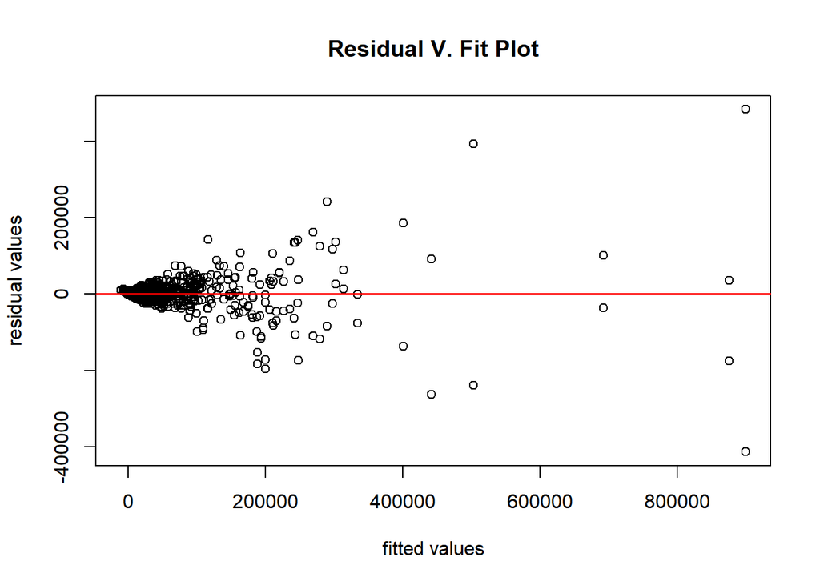

```
## integer(0)
```

```r
#Get residuals and fitted values, create residuals v. fit plot
res <- resid(reg.full)
fit <- fitted(reg.full)

plot(x=fit,y=res, xlab='fitted values', ylab='residual values', main='Residual V. Fit Plot')+
  abline(h=0,col='red')
```

There is a clear nonconstant variances with our residuals, along with noticable outliers. We have a fanning effect, with our residuals being close to 0 for small x-values, but increasing with larger ones.

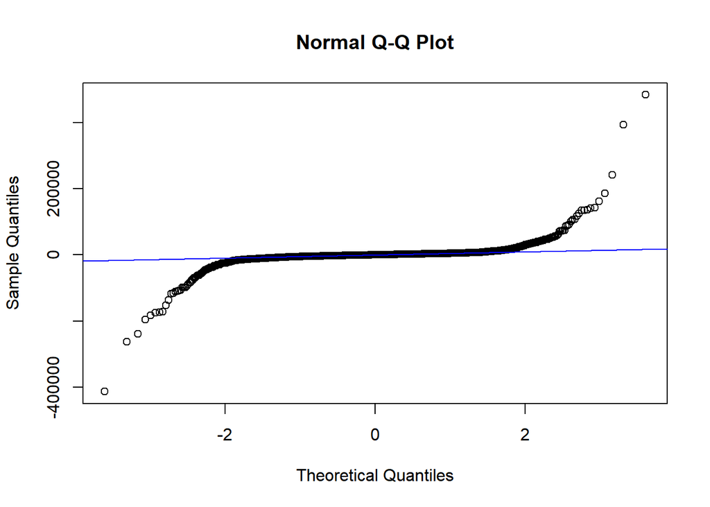

```r
#qqnorm Plot
qqnorm(res)
qqline(res,col='blue')
```

The qqnorm plot indicates our residuals are not normally distributed. There’s also clear outliers in the data that’s likely affected the model. Let’s create a box-cox error plot to validate these claims. If our estimated value of lambda has 1 within it’s 95% confidence interval, then we may assume normality. If not, we’ll need to transform the data in some way to fix this.

```r
library(MASS)
bcox <- boxcox(reg.full)
```

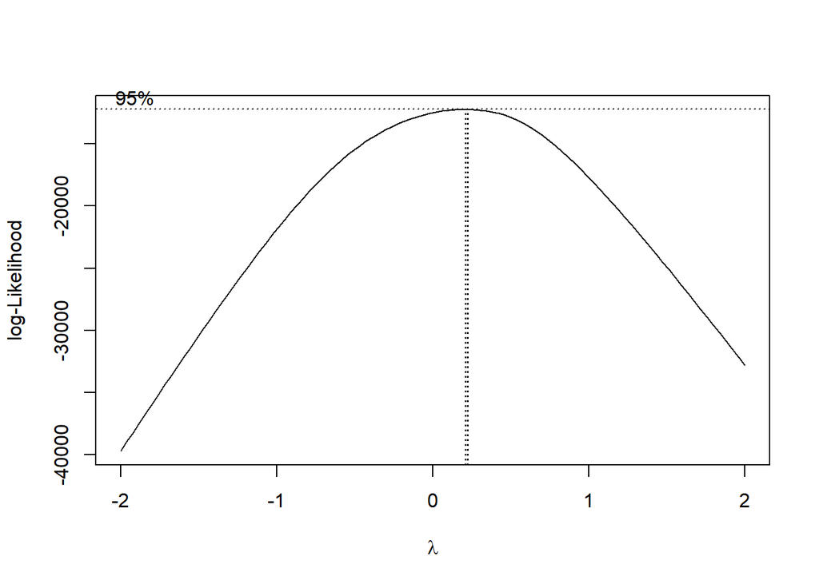

```r
bcox
```

[output not shown]

[output cut: 20 more lines]

We can also use a shapiro-wilks test. In the shapiro-wilks test, we assume for the null hypothesis that residuals are normally distributed. We obtain a p-value less than 0.05, thus rejecting the null hypothesis. The residuals are clearly not normally distributed.

```r
shapiro.test(res)
```

```
##
##  Shapiro-Wilk normality test
##
## data:  res
## W = 0.37582, p-value < 0.00000000000000022
```

So it is true, our residuals are not normally distributed and as such LINE conditions are not met. We’ll need to transform our response in some way to fulfill LINE conditions. Since 0 doesn’t fall into the 95% confidence interval for the boxcox transform, we’ll take the value of lambda we have and use a boxcox transformation on the votes parameter

```r
lambda <- bcox$x[which.max(bcox$y)]
lambda
```

```
## [1] 0.2222222
```

```r
reg.transform <- lm(y**lambda~x1+x20+x14+x24+x16+x15+x23+x22+x25+
              x1_2+x14_2+x15_2+x20_2+x22_2+x23_2+x24_2+x25_2+
              x1_3+x14_3+x15_3+x20_3+x22_3+x24_3+
              x14_4+x20_4+x22_4+x24_4+
              x20_5+
              x20_6+
              x20_7+
              x20_8)
```

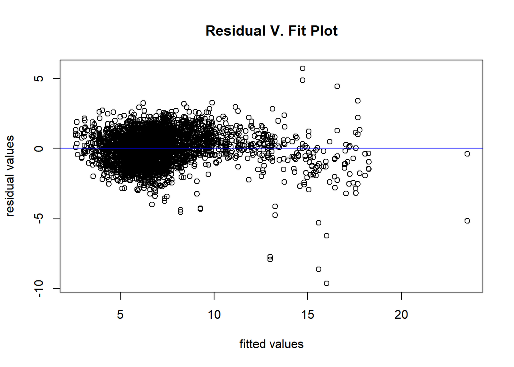

```
## integer(0)
```

```r
#New residual v. fit plot
res <- resid(reg.transform)
fit <- fitted(reg.transform)

plot(x=fit,y=res, xlab='fitted values', ylab='residual values', main='Residual V. Fit Plot')+
  abline(h=0,col='blue')
```

The residuals seem to be much more constant than before, but we still have a cone shape.

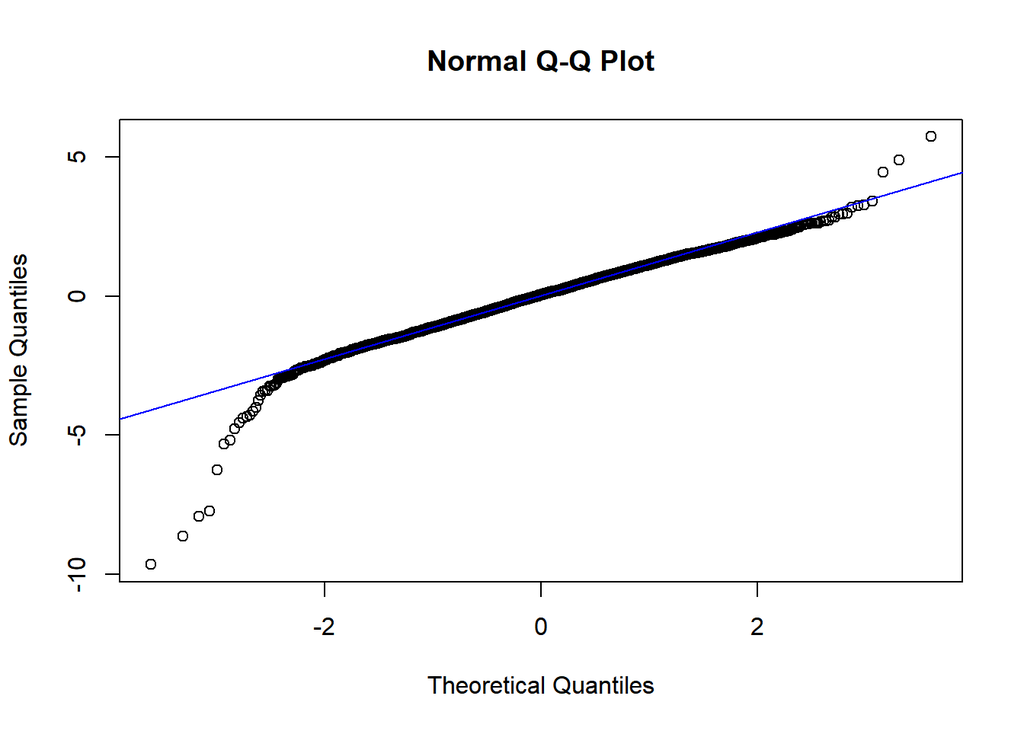

```r
#qqnorm Plot
qqnorm(res)
qqline(res,col='blue')
```

Our data appears much more normally distributed, but there’s still an apperent left skew.

```r
shapiro.test(res)
```

```
##
##  Shapiro-Wilk normality test
##
## data:  res
## W = 0.97018, p-value < 0.00000000000000022
```

The shapiro wilks test still rejects the null hyothesis. At this point, my knowledge on the subject has ran its course. There’s a case to consider outliers and high leverage data, there are noticable outliers and possible high leverage data that we can observe from our plots and would likely find in further analysis. However, there is no reason to assume the given data is incorrect, and so they should not be excluded from the data.

I’m going to check the models predictions and see how it performed.

```r
#Get our regression data, minus votes
election.reg.data <- data.frame(TotalPop,Professional,Service,Office,Transit,WorkAtHome,MeanCommute,PrivateWork,SelfEmployed)
#predict the data and add as a column to our original data frame.
reg.pred <- predict(reg.transform,election.reg.data)
```

```r
election.reg$reg.pred <- reg.pred**(1/.22)
election.reg
```

```
## # A tibble: 3,222 x 33
##    state          county     candidate votes CountyId TotalPop   Men Women White
##    <chr>          <chr>      <fct>     <dbl>    <dbl>    <dbl> <dbl> <dbl> <dbl>
##  1 georgia        paulding   Joe Biden 29658    13223   152399  48.9  51.1  73
##  2 north carolina alleghany  Donald T~  4501    37005    10935  49.8  50.2  87.3
##  3 louisiana      pointe co~ Donald T~  7503    22077    22271  48.0  52.0  60.4
##  4 tennessee      stewart    Donald T~  4942    47161    13248  49.7  50.3  92
##  5 wisconsin      iowa       Joe Biden  7828    55049    23576  50.3  49.7  95.6
##  6 minnesota      blue earth Donald T~ 16721    27013    65767  50.3  49.7  88.9
##  7 arizona        yuma       Joe Biden 31562     4027   204281  51.4  48.6  31.8
##  8 illinois       bond       Donald T~  5612    17005    17034  51.5  48.5  87.8
##  9 virginia       halifax    Donald T~ 10404    51083    35030  47.1  52.9  59.8
## 10 iowa           humboldt   Joe Biden  1442    19091     9586  48.7  51.3  94
## # ... with 3,212 more rows, and 24 more variables: VotingAgeCitizen <dbl>,
## #   Income <dbl>, Poverty <dbl>, ChildPoverty <dbl>, Professional <dbl>,
## #   Service <dbl>, Office <dbl>, Production <dbl>, Drive <dbl>, Carpool <dbl>,
## #   Transit <dbl>, OtherTransp <dbl>, WorkAtHome <dbl>, MeanCommute <dbl>,
## #   Employed <dbl>, PrivateWork <dbl>, SelfEmployed <dbl>, FamilyWork <dbl>,
## #   Unemployment <dbl>, Minority <dbl>, biden <dbl>, trump <dbl>,
## #   votes_pred <dbl>, reg.pred <dbl>
```

```r
#Similar to the initial analysis and regularized regression models, create dataframes of predicted county and state values
election.reg.county <- election.reg
election.reg.state <- election.reg %>% group_by(state,candidate) %>% summarise(reg.pred=sum(reg.pred))
#county.winner (predicted)
pred.county.winner <- election.reg.county %>%
  group_by(county) %>%
  mutate(total=sum(reg.pred)) %>%
  mutate(pct=reg.pred/total) %>%
  top_n(n=1, wt=pct)
pred.county.winner
```

```
## # A tibble: 2,194 x 35
## # Groups:   county [1,097]
##    state        county      candidate  votes CountyId TotalPop   Men Women White
##    <chr>        <chr>       <fct>      <dbl>    <dbl>    <dbl> <dbl> <dbl> <dbl>
##  1 georgia      paulding    Joe Biden  29658    13223   152399  48.9  51.1  73
##  2 louisiana    pointe cou~ Donald Tr~  7503    22077    22271  48.0  52.0  60.4
##  3 tennessee    stewart     Donald Tr~  4942    47161    13248  49.7  50.3  92
##  4 wisconsin    iowa        Joe Biden   7828    55049    23576  50.3  49.7  95.6
##  5 minnesota    blue earth  Donald Tr~ 16721    27013    65767  50.3  49.7  88.9
##  6 arizona      yuma        Joe Biden  31562     4027   204281  51.4  48.6  31.8
##  7 illinois     bond        Donald Tr~  5612    17005    17034  51.5  48.5  87.8
##  8 virginia     halifax     Donald Tr~ 10404    51083    35030  47.1  52.9  59.8
##  9 colorado     gilpin      Donald Tr~  1815     8047     5793  53.7  46.3  86.2
## 10 pennsylvania clearfield  Joe Biden   9598    42033    80539  52.1  47.9  93.1
## # ... with 2,184 more rows, and 26 more variables: VotingAgeCitizen <dbl>,
## #   Income <dbl>, Poverty <dbl>, ChildPoverty <dbl>, Professional <dbl>,
## #   Service <dbl>, Office <dbl>, Production <dbl>, Drive <dbl>, Carpool <dbl>,
## #   Transit <dbl>, OtherTransp <dbl>, WorkAtHome <dbl>, MeanCommute <dbl>,
## #   Employed <dbl>, PrivateWork <dbl>, SelfEmployed <dbl>, FamilyWork <dbl>,
## #   Unemployment <dbl>, Minority <dbl>, biden <dbl>, trump <dbl>,
## #   votes_pred <dbl>, reg.pred <dbl>, total <dbl>, pct <dbl>
```

```r
#state.winner (predicted)
pred.state.winner <- election.reg.state %>%
  group_by(state) %>%
  mutate(total=sum(reg.pred)) %>%
  mutate(pct=reg.pred/total) %>%
  top_n(n=1, wt=pct)
pred.state.winner
```

```
## # A tibble: 96 x 5
## # Groups:   state [48]
##    state      candidate    reg.pred    total   pct
##    <chr>      <fct>           <dbl>    <dbl> <dbl>
##  1 alabama    Donald Trump  677332. 1354664.   0.5
##  2 alabama    Joe Biden     677332. 1354664.   0.5
##  3 arizona    Donald Trump  165529.  331058.   0.5
##  4 arizona    Joe Biden     165529.  331058.   0.5
##  5 arkansas   Donald Trump  354450.  708900.   0.5
##  6 arkansas   Joe Biden     354450.  708900.   0.5
##  7 california Donald Trump 1748726. 3497452.   0.5
##  8 california Joe Biden    1748726. 3497452.   0.5
##  9 colorado   Donald Trump  822086. 1644171.   0.5
## 10 colorado   Joe Biden     822086. 1644171.   0.5
## # ... with 86 more rows
```

```r
#Predicted Results
states.join <- left_join(states, pred.state.winner)
```

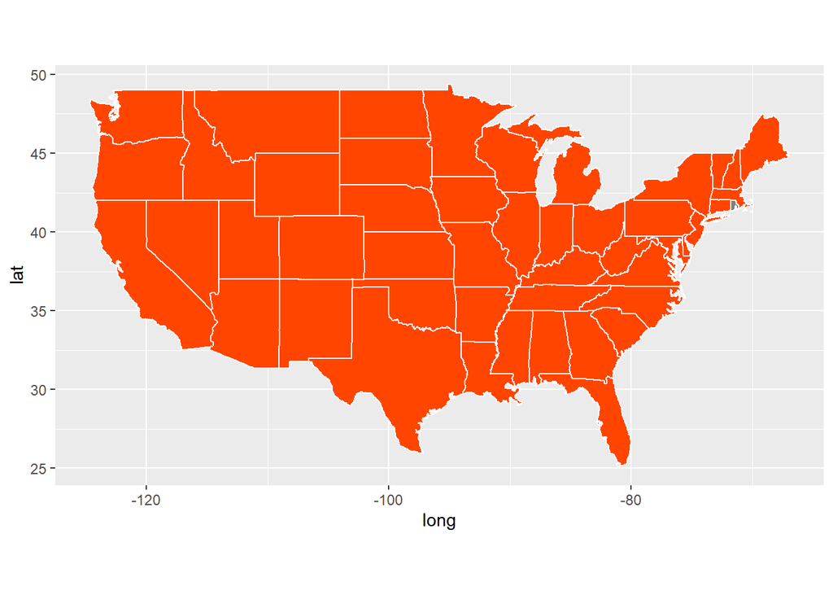

```r
ggplot(data=states.join)+
  geom_polygon(aes(x=long, y=lat, fill=candidate, group=group), color='white') +
  coord_fixed(1.3) +
  scale_fill_manual(values=c('orangered','steelblue')) + theme(legend.position='none')
```

```r
#added custom colors for aesthetic
```

There’s a tie in every state, likely because biden or trump predictors were not included in the final model.

If further work in this analysis were to be considered, I would seriously include the inclusion of either the biden or trump dummy variables regardless of statistical signfigance. That seems to be the only way to make meaning of the difference of votes for each county.

*Final Thoughts*

My work on classification seems to have done a better job in making accurate predictions towards election results. For that I can say it’s relatively small error rate has me satisfied.

Do the nature of the Transit predictor, counties with higher rates of transit IE more urban populations, ie higher rates of cities are very influential for the classification models, as well as the model in regression analysis.